# Multivariate TS Models

## Multivariate Analysis

Based on the data and previous univariate analysis, we will begin conducting multivariate analysis in this section. Our data science questions include:

- What factors interact with the US Dollar Index?
- What exogenous variables affect the US Dollar Index?
- What factors are influenced by the US Dollar Index?

Before constructing Multivariate Time Series Models, we will first conduct a literature review ([see the Introduction part](https://binghuini.github.io/_site_ts_usd_index/introduction.html#literature-review)) and analyze the mechanisms among variables from an economic perspective.

### Interacting Variables

**Trade Balance**

- **Trade Deficit → Dollar Depreciation**: Higher imports than exports lead to a trade deficit, requiring capital inflows but increasing dollar supply, causing depreciation.
- **Dollar Depreciation → Trade Deficit Reduction**: A weaker dollar boosts US exports and reduces imports, helping balance the deficit.
- The expansion of the trade deficit leads to the depreciation of the US dollar.

  A trade deficit means that the US imports more than it exports. According to the `Balance of Payments Identity` (Current Account + Financial Account = 0), a trade deficit (i.e., a negative current account) means that the financial account must be positive. This is reflected in capital inflows. Typically, the US issues government bonds and attracts foreign investment to balance the trade deficit. However, the increased supply of dollars in the foreign exchange market will cause the dollar to depreciate, or foreign investors may become concerned about the US fiscal situation, leading to reduced demand for the dollar and further depreciation.
- The depreciation of the dollar leads to a reduction in the trade deficit.

  When the dollar depreciates, US goods and services become relatively cheaper in international markets, which may increase US exports. At the same time, imported goods become relatively expensive, leading to a reduction in US imports. Therefore, the depreciation of the dollar generally reduces the trade deficit.

**Global Commodity Market**

- A stronger dollar leads to a decrease in global commodity prices.

  Since the dollar is the global reserve and trading currency, commodities (such as oil, gold, copper, aluminum, etc.) are typically priced in dollars. When the dollar appreciates, the cost for holders of other currencies to buy dollar-priced commodities increases, which leads to a reduction in demand and lowers commodity prices. Additionally, investors may shift funds from physical assets like commodities into dollar-denominated assets, further driving down commodity prices.
- Changes in commodity prices also influence the US Dollar Index.

  A rise in commodity prices, especially oil and metal prices, often puts pressure on global inflation. This, in turn, affects the Dollar Index. Moreover, commodity price fluctuations often reflect changes in the global economy. For example, an increase in oil prices may indicate a slowdown in global economic growth or supply-demand imbalances. These factors could lead to higher demand for the dollar as a safe-haven currency, thus pushing up the Dollar Index.

**Stock Market**

- The risk and return associated with stocks are relatively high, and the dollar can serve as a safe-haven asset. Therefore, there is a competitive relationship between the two. Generally speaking, the stock market and the Dollar Index have an inverse relationship. When global investors have a higher risk appetite or when the stock market is strong, capital tends to flow into the stock market. This reduces demand for the dollar and leads to a depreciation of the dollar. On the other hand, when the dollar appreciates, investors may prefer to move funds into low-risk assets like bonds. This leads to capital outflows from the stock market and puts downward pressure on it, especially on overvalued stocks. However, a stronger dollar may also reflect a robust economy, which could push stock prices higher.

**Gold Market**

- The dollar and gold also tend to show inverse fluctuations due to their competitive relationship.
- A stronger dollar leads to a decrease in gold prices.

  First, gold prices are usually denominated in dollars. When the dollar appreciates, the cost of gold in other currencies increases, reducing demand and lowering gold prices. Secondly, a stronger dollar may be due to the Federal Reserve raising interest rates. In this case, investors are more likely to invest in higher-yielding assets (such as dollar-denominated bonds) and reduce holdings in non-interest-bearing assets like gold, leading to a decline in gold prices.
- An increase in gold prices leads to the depreciation of the dollar.

  When the dollar weakens or global economic uncertainty rises, the dollar may no longer be considered a safe-haven asset, and gold becomes the preferred choice. Investors may tend to buy gold as a hedge against inflation or currency devaluation, leading to decreased demand for the dollar and causing it to depreciate.

**GDP**

- Economic growth drives dollar appreciation.

  When a country’s GDP grows strongly, it typically reflects good economic performance and attracts foreign investors’ attention. This capital inflow (e.g., foreign direct investment, securities investment) increases demand for the country’s currency, which in our case is the US dollar, leading to dollar appreciation.

**Unemployment Rate**

- A higher unemployment rate leads to dollar depreciation.
  - **Mechanism 1**

    The unemployment rate mainly affects the economy, which in turn influences the Dollar Index. There is an inverse relationship between the unemployment rate and GDP growth. A higher unemployment rate typically indicates an economic recession or depression, where businesses reduce hiring, which is often accompanied by a decrease in consumption and investment. This reduces the ability to attract foreign investment into the US, leading to reduced demand for dollar-denominated assets and a depreciation of the dollar.
  - **Mechanism 2**

    When the unemployment rate is high, the Federal Reserve may adopt loose monetary policies (e.g., lowering interest rates or quantitative easing) to stimulate the economy and reduce unemployment. Such loose monetary policies typically lead to dollar depreciation because lower interest rates reduce the relative attractiveness of the dollar, making it less likely to attract foreign capital inflows, thereby decreasing demand for the dollar.

**CPI**

- An increase in the CPI drives dollar appreciation.

  When the CPI rises, it indicates inflation. In this case, the Federal Reserve may adopt a tightening monetary policy, such as raising interest rates, to control inflation. Higher interest rates make the dollar more attractive because they can attract foreign capital inflows, increasing demand for the dollar and thus driving up its value.

  Expectations are also a factor. If inflation expectations rise, markets may anticipate that the Federal Reserve will take more tightening measures, which could lead to dollar appreciation.

### Exogenous Variables

**Real Estate Market**

- A stronger dollar typically indicates a relatively strong US economy, and interest rates may rise. Higher mortgage rates increase borrowing costs, which can suppress demand for housing and lead to a decline in housing prices.
- However, a stronger dollar can also boost confidence among homebuyers and global investors. This leads to increased capital inflows into US real estate, pushing housing prices up.

Therefore, the impact may be a combined effect.

**Tourism**

- When the dollar appreciates, foreign tourists need to exchange more of their local currency for dollars, which increases their travel costs. Some tourists may opt for other travel destinations, leading to a decrease in the number of tourists visiting the US. Therefore, US tourism may decline with a stronger dollar.

```r
library(tidyverse)
library(ggplot2)
library(forecast)
library(astsa)
library(xts)
library(zoo)
library(tseries)
library(fpp2)
library(fma)
library(lubridate)
library(tidyverse)
library(TSstudio)
library(quantmod)
library(tidyquant)
library(plotly)
library(readr)
library(dplyr)
library(kableExtra)
library(knitr)
library(patchwork)
library(vars)

# Load data
invisible(getSymbols("DX-Y.NYB", src = "yahoo", from = "2005-01-01", to = "2024-12-31"))
dxy <- data.frame(Date = index(`DX-Y.NYB`),
                       Open = `DX-Y.NYB`[, "DX-Y.NYB.Open"],
                       High = `DX-Y.NYB`[, "DX-Y.NYB.High"],
                       Low = `DX-Y.NYB`[, "DX-Y.NYB.Low"],
                       Close = `DX-Y.NYB`[, "DX-Y.NYB.Close"])
colnames(dxy) <- c("Date", "Open", "High", "Low", "Close")
dxy <- na.omit(dxy)

bea <- read.csv("./data/bea.csv")
bea$time <- as.Date(bea$time)

gdp <- read.csv("./data/gdp.csv")
gdp$time <- as.Date(gdp$time)
gdp$total <- gdp$consumption + gdp$investment + gdp$net_export + gdp$government

data_unem <- read.csv("./data/unem.csv", header=TRUE)
data_unem$time <- as.Date(data_unem$time)

data_cpi <- read.csv("./data/cpi.csv", header=TRUE)
data_cpi$time <- as.Date(data_cpi$time)

invisible(getSymbols("^GSPC", src = "yahoo", from = "2005-01-01", to = "2024-12-31"))
invisible(getSymbols("BTC-USD", src = "yahoo", from = "2015-01-01", to = "2024-12-31"))

xau <- read.csv("./data/xau.csv")
xau$Date <- as.Date(xau$Date)

gsci <- read.csv("./data/gsci.csv")[2:2518,]
gsci$Date <- as.Date(gsci$Date)

house <- read.csv("./data/house.csv", header=TRUE)
house$time <- as.Date(house$time)

visitors <- read.csv("./data/visitors.csv", header=TRUE)
visitors$time <- as.Date(visitors$time)

egg <- read.csv("./data/eggs_price.csv")
egg$Date <- as.Date(egg$Date)

ir <- read.csv("./data/interest_rate.csv")
ir$Date <- as.Date(ir$Date)

oil <- read.csv("./data/oil_price.csv")
oil$Date <- as.Date(oil$Date)

set.seed(123)
library(kableExtra)

# ARIMA funtion
ARIMA.c = function(p1, p2, q1, q2, data) {
  d = 1
  i = 1
  temp = data.frame()
  ls = matrix(rep(NA, 6 * 100), nrow = 100)

  for (p in p1:p2) {
    for (q in q1:q2) {
          if (p + d + q <= 9) {

            model <- tryCatch({
              Arima(data, order = c(p, d, q), include.drift = TRUE)
            }, error = function(e) {
              return(NULL)
            })

            if (!is.null(model)) {
              ls[i, ] = c(p, d, q, model$aic, model$bic, model$aicc)
              i = i + 1
            }
          }
        }
      }
      temp = as.data.frame(ls)
      names(temp) = c("p", "d", "q", "AIC", "BIC", "AICc")
      temp = na.omit(temp)
      return(temp)
}

# SARIMA function
SARIMA.c = function(p1, p2, q1, q2, P1, P2, Q1, Q2, s, data) {
  d = 1
  D = 1
  i = 1
  temp = data.frame()
  ls = matrix(rep(NA, 9 * 100), nrow = 100)

  for (p in p1:p2) {
    for (q in q1:q2) {
      for (P in P1:P2) {
        for (Q in Q1:Q2) {
          if (p + d + q + P + D + Q <= 9) {

            model <- tryCatch({
              Arima(data, order = c(p, d, q), seasonal = list(order = c(P,D,Q), period = s))
            }, error = function(e) {
              return(NULL)
            })

            if (!is.null(model)) {
              ls[i, ] = c(p, d, q, P, D, Q, model$aic, model$bic, model$aicc)
              i = i + 1
            }
          }
        }
      }
    }
  }

  temp = as.data.frame(ls)
  names(temp) = c("p", "d", "q", "P", "D", "Q", "AIC", "BIC", "AICc")
  temp = na.omit(temp)
  return(temp)
}

highlight_output = function(output, type="ARIMA") {
    highlight_row <- c(which.min(output$AIC), which.min(output$BIC), which.min(output$AICc))
    knitr::kable(output, align = 'c', caption = paste("Comparison of", type, "Models")) %>%
    kable_styling(full_width = FALSE, position = "center") %>%
    row_spec(highlight_row, bold = TRUE, background = "#FFFF99")  # Highlight row in yellow
}

# Define a function to fit SARIMA and handle errors
fit_sarima <- function(xtrain, p, d, q, P, D, Q, s) {
  fit <- tryCatch({
    Arima(xtrain, order = c(p, d, q), seasonal = list(order = c(P, D, Q), period = s),
          include.drift = FALSE, lambda = 0, method = "ML")
  }, error = function(e) {
    return(NULL)  # Return NULL if an error occurs
  })
  return(fit)  # Return the fitted model (or NULL)
}
```

## VAR: USD ~ Trade Deficit + Global Commodity Price + CPI

Here, we will analyze the interactions between the USD, trade deficit, global commodity prices, and CPI.

**Time Series Plot**

```r
dxy_m <- dxy %>%
  mutate(month = floor_date(Date, "month")) %>%
  group_by(month) %>%
  summarise(Close = mean(Close, na.rm = TRUE))
dxy_q <- dxy %>%
  mutate(quarter = floor_date(Date, "quarter")) %>%
  group_by(quarter) %>%
  summarise(Close = mean(Close, na.rm = TRUE))
gsci_q <- gsci %>%
  mutate(quarter = floor_date(Date, "quarter")) %>%
  group_by(quarter) %>%
  summarise(gsci = mean(Price, na.rm = TRUE))
cpi_q <- data_cpi %>%
  mutate(quarter = floor_date(time, "quarter")) %>%
  group_by(quarter) %>%
  summarise(cpi = mean(cpi, na.rm = TRUE))

df1 <- data.frame(Date = gsci_q$quarter,
                  USD = log(dxy_q$Close)[41:80],
                  Deficit = log(abs(bea$balance))[41:80],
                  CommodityPrice = log(gsci_q$gsci),
                  CPI = log(cpi_q$cpi)[41:80]
                  )

plot_usd <- plot_ly(df1, x = ~Date, y = ~USD, type = 'scatter', mode = 'lines', name = 'U.S. Dollar')
plot_deficit <- plot_ly(df1, x = ~Date, y = ~Deficit, type = 'scatter', mode = 'lines', name = 'Trade Deficit')
plot_gsci <- plot_ly(df1, x = ~Date, y = ~CommodityPrice, type = 'scatter', mode = 'lines', name = 'Commodity Price')
plot_cpi <- plot_ly(df1, x = ~Date, y = ~CPI, type = 'scatter', mode = 'lines', name = 'CPI')

subplot(plot_usd, plot_deficit, plot_gsci, plot_cpi, nrows = 4, shareX = TRUE) %>%
  layout(title = "Trend of U.S. Dollar and Related Variables", showlegend = FALSE,
    xaxis = list(title = 'Date'),
    yaxis = list(title = 'U.S. Dollar'),
    yaxis2 = list(title = 'Trade Deficit'),
    yaxis3 = list(title = 'Commodity Price'),
    yaxis4 = list(title = 'CPI'))
```

[interactive chart not shown]

**Parameter(p) Selection**

```r
ts_df1 <- ts(df1[,-1], start = c(2015,1), frequency = 4)
VARselect(ts_df1, lag.max=6, type="both")
```

```
$selection
AIC(n)  HQ(n)  SC(n) FPE(n)
     6      6      1      2

$criteria
                   1             2             3             4             5
AIC(n) -2.787866e+01 -2.851355e+01 -2.862475e+01 -2.831302e+01 -2.893424e+01
HQ(n)  -2.751123e+01 -2.790116e+01 -2.776740e+01 -2.721072e+01 -2.758698e+01
SC(n)  -2.680123e+01 -2.671783e+01 -2.611074e+01 -2.508073e+01 -2.498366e+01
FPE(n)  7.923879e-13  4.444468e-13  4.556769e-13  8.165450e-13  7.276663e-13
                   6
AIC(n) -2.997350e+01
HQ(n)  -2.838128e+01
SC(n)  -2.530463e+01
FPE(n)  6.699754e-13
```

Based on the results, the lag length could be 1, 2, or 6.

**Fit Models**

```r
summary(fit <- VAR(ts_df1, p=1, type="both"))
```

```
VAR Estimation Results:
=========================
Endogenous variables: USD, Deficit, CommodityPrice, CPI
Deterministic variables: both
Sample size: 39
Log Likelihood: 342.132
Roots of the characteristic polynomial:
0.8721 0.8113 0.8113 0.3509
Call:
VAR(y = ts_df1, p = 1, type = "both")


Estimation results for equation USD:
====================================
USD = USD.l1 + Deficit.l1 + CommodityPrice.l1 + CPI.l1 + const + trend

                   Estimate Std. Error t value Pr(>|t|)
USD.l1             0.667614   0.124027   5.383 5.96e-06 ***
Deficit.l1         0.004326   0.026047   0.166   0.8691
CommodityPrice.l1  0.069535   0.029550   2.353   0.0247 *
CPI.l1             0.248191   0.232994   1.065   0.2945
const             -0.289282   0.914592  -0.316   0.7538
trend             -0.002214   0.001532  -1.445   0.1578
---
Signif. codes:  0 '***' 0.001 '**' 0.01 '*' 0.05 '.' 0.1 ' ' 1


Residual standard error: 0.02053 on 33 degrees of freedom
Multiple R-Squared: 0.8444, Adjusted R-squared: 0.8208
F-statistic: 35.81 on 5 and 33 DF,  p-value: 2.07e-12


Estimation results for equation Deficit:
========================================
Deficit = USD.l1 + Deficit.l1 + CommodityPrice.l1 + CPI.l1 + const + trend

                   Estimate Std. Error t value Pr(>|t|)
USD.l1            -1.498555   0.747045  -2.006   0.0531 .
Deficit.l1         0.421178   0.156890   2.685   0.0113 *
CommodityPrice.l1  0.030080   0.177986   0.169   0.8668
```

[output cut: 51 more lines]

```


Covariance matrix of residuals:
                      USD    Deficit CommodityPrice        CPI
USD             4.217e-04 -0.0001257     -0.0003646 -1.961e-05
Deficit        -1.257e-04  0.0152973      0.0011320  2.837e-04
CommodityPrice -3.646e-04  0.0011320      0.0073263  4.279e-04
CPI            -1.961e-05  0.0002837      0.0004279  4.046e-05

Correlation matrix of residuals:
                   USD Deficit CommodityPrice     CPI
USD             1.0000 -0.0495        -0.2075 -0.1501
Deficit        -0.0495  1.0000         0.1069  0.3606
CommodityPrice -0.2075  0.1069         1.0000  0.7860
CPI            -0.1501  0.3606         0.7860  1.0000
```

```r
summary(fit <- VAR(ts_df1, p=2, type="both"))
```

```
VAR Estimation Results:
=========================
Endogenous variables: USD, Deficit, CommodityPrice, CPI
Deterministic variables: both
Sample size: 38
Log Likelihood: 359.881
Roots of the characteristic polynomial:
0.8411 0.7931 0.7931 0.7212 0.7212 0.5164 0.5164 0.04401
Call:
VAR(y = ts_df1, p = 2, type = "both")


Estimation results for equation USD:
====================================
USD = USD.l1 + Deficit.l1 + CommodityPrice.l1 + CPI.l1 + USD.l2 + Deficit.l2 + CommodityPrice.l2 + CPI.l2 + const + trend

                   Estimate Std. Error t value Pr(>|t|)
USD.l1             0.860943   0.176984   4.865 4.02e-05 ***
Deficit.l1        -0.034702   0.031732  -1.094   0.2835
CommodityPrice.l1 -0.049823   0.069952  -0.712   0.4822
CPI.l1             1.999967   0.992855   2.014   0.0537 .
USD.l2            -0.374902   0.180288  -2.079   0.0468 *
Deficit.l2         0.034468   0.033392   1.032   0.3108
CommodityPrice.l2  0.034555   0.050941   0.678   0.5031
CPI.l2            -1.375498   0.904893  -1.520   0.1397
const             -0.959290   1.024171  -0.937   0.3569
trend             -0.003810   0.001726  -2.208   0.0356 *
---
Signif. codes:  0 '***' 0.001 '**' 0.01 '*' 0.05 '.' 0.1 ' ' 1


Residual standard error: 0.02 on 28 degrees of freedom
Multiple R-Squared: 0.8741, Adjusted R-squared: 0.8337
F-statistic: 21.61 on 9 and 28 DF,  p-value: 2.388e-10


Estimation results for equation Deficit:
========================================
Deficit = USD.l1 + Deficit.l1 + CommodityPrice.l1 + CPI.l1 + USD.l2 + Deficit.l2 + CommodityPrice.l2 + CPI.l2 + const + trend

```

[output cut: 67 more lines]

```


Covariance matrix of residuals:
                      USD    Deficit CommodityPrice        CPI
USD             3.998e-04 -0.0005604     -0.0004343 -3.436e-05
Deficit        -5.604e-04  0.0092876      0.0020977  2.978e-04
CommodityPrice -4.343e-04  0.0020977      0.0074725  4.054e-04
CPI            -3.436e-05  0.0002978      0.0004054  3.623e-05

Correlation matrix of residuals:
                   USD Deficit CommodityPrice     CPI
USD             1.0000 -0.2908        -0.2512 -0.2855
Deficit        -0.2908  1.0000         0.2518  0.5134
CommodityPrice -0.2512  0.2518         1.0000  0.7791
CPI            -0.2855  0.5134         0.7791  1.0000
```

```r
summary(fit <- VAR(ts_df1, p=6, type="both"))
```

```
VAR Estimation Results:
=========================
Endogenous variables: USD, Deficit, CommodityPrice, CPI
Deterministic variables: both
Sample size: 34
Log Likelihood: 420.574
Roots of the characteristic polynomial:
0.9774 0.9774 0.9612 0.9612 0.9551 0.9537 0.9537 0.9456 0.9456 0.914 0.8946 0.8946 0.8791 0.8791 0.874 0.874 0.8692 0.8692 0.8455 0.8455 0.8179 0.8179 0.4034 0.04809
Call:
VAR(y = ts_df1, p = 6, type = "both")


Estimation results for equation USD:
====================================
USD = USD.l1 + Deficit.l1 + CommodityPrice.l1 + CPI.l1 + USD.l2 + Deficit.l2 + CommodityPrice.l2 + CPI.l2 + USD.l3 + Deficit.l3 + CommodityPrice.l3 + CPI.l3 + USD.l4 + Deficit.l4 + CommodityPrice.l4 + CPI.l4 + USD.l5 + Deficit.l5 + CommodityPrice.l5 + CPI.l5 + USD.l6 + Deficit.l6 + CommodityPrice.l6…

                   Estimate Std. Error t value Pr(>|t|)
USD.l1             0.188522   0.278061   0.678   0.5169
Deficit.l1        -0.114187   0.063291  -1.804   0.1089
CommodityPrice.l1 -0.088524   0.097296  -0.910   0.3895
CPI.l1             3.503156   1.427231   2.455   0.0397 *
USD.l2             0.063782   0.272373   0.234   0.8207
Deficit.l2        -0.023496   0.063565  -0.370   0.7212
CommodityPrice.l2  0.131369   0.096624   1.360   0.2110
CPI.l2            -1.958538   2.251024  -0.870   0.4096
USD.l3            -0.447982   0.274821  -1.630   0.1417
Deficit.l3        -0.138874   0.067914  -2.045   0.0751 .
CommodityPrice.l3 -0.110289   0.095874  -1.150   0.2832
CPI.l3             0.835259   1.921125   0.435   0.6752
USD.l4            -0.251535   0.275764  -0.912   0.3884
Deficit.l4         0.002074   0.066215   0.031   0.9758
CommodityPrice.l4 -0.171482   0.095911  -1.788   0.1116
CPI.l4             0.707427   1.943709   0.364   0.7253
USD.l5            -0.320172   0.227445  -1.408   0.1969
Deficit.l5        -0.007782   0.056297  -0.138   0.8935
CommodityPrice.l5  0.084407   0.081619   1.034   0.3313
CPI.l5            -1.363133   1.779101  -0.766   0.4656
USD.l6            -0.459738   0.277596  -1.656   0.1363
Deficit.l6         0.083523   0.053758   1.554   0.1589
CommodityPrice.l6  0.059224   0.061525   0.963   0.3639
```

[output cut: 127 more lines]

```


Covariance matrix of residuals:
                      USD   Deficit CommodityPrice       CPI
USD             2.227e-04 5.909e-05     -4.855e-05 9.372e-06
Deficit         5.909e-05 4.108e-03      2.520e-03 1.162e-04
CommodityPrice -4.855e-05 2.520e-03      1.147e-02 6.200e-04
CPI             9.372e-06 1.162e-04      6.200e-04 4.198e-05

Correlation matrix of residuals:
                    USD Deficit CommodityPrice     CPI
USD             1.00000 0.06178       -0.03038 0.09694
Deficit         0.06178 1.00000        0.36701 0.27992
CommodityPrice -0.03038 0.36701        1.00000 0.89346
CPI             0.09694 0.27992        0.89346 1.00000
```

The model with p=1 or p=2 looks good. However, only a few variables are significant in the model with p=6, suggesting that VAR(6) may not be the best choice.

**Cross Validation**

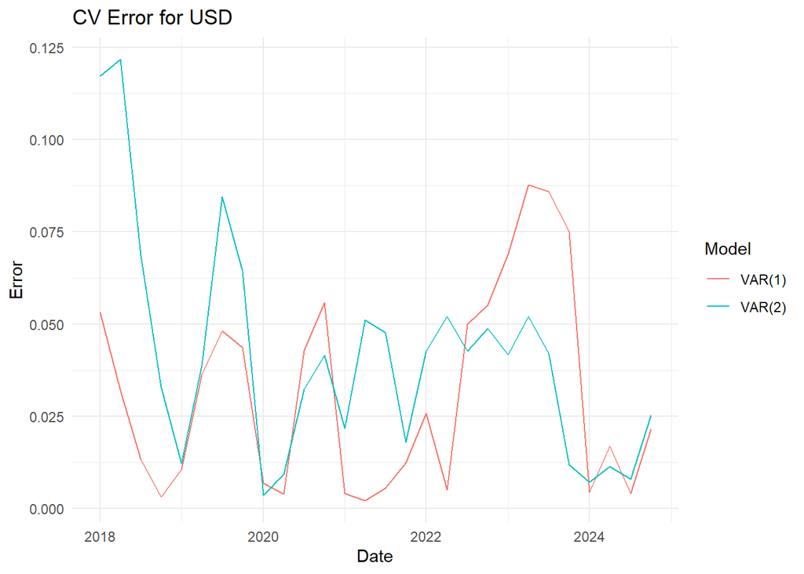

```r
fun.var <- function(ts, year, p, s){
  fit <- VAR(ts, p=p, type='both')
  fcast <- predict(fit, n.ahead = s)

  f1<-fcast$fcst$USD
  f2<-fcast$fcst$Deficit
  f3<-fcast$fcst$CommodityPrice
  f4<-fcast$fcst$CPI
  ff<-data.frame(f1[,1],f2[,1],f3[,1],f4[,1])
  ff<-ts(ff,start=c(year,1),frequency = s)
  return(ff)
}

data <- ts_df1
n=nrow(data)
n_var = ncol(data)
h <- 4  # h: Forecast horizon
# k: Initial training set
# Calculate k as 1/3rd of the data, rounded down to the nearest multiple of 12
k <- floor(n / 3 / h) * h
num_iter <- (n - k) / h  # Number of rolling iterations

# Initialize matrices for RMSE
rmse1 <- matrix(NA, nrow = n-k, ncol = n_var)  # RMSE for Model 1
rmse2 <- matrix(NA, nrow = n-k, ncol = n_var)  # RMSE for Model 2

# Define rolling start time
st <- tsp(data)[1] + (k - 1) / h

# Walk-Forward Validation Loop
for (i in 1:num_iter) {
  xtrain <- window(data, end = st + i - 1)
  xtest <- window(data, start = st + (i - 1) + 1/h, end = st + i)  # Test set for the next 12 months
  test_start_year <- st + (i-1) + 1/h #starting year for predication, i.e. xtest

  ######## VAR(1) ############
  ff1 <- fun.var(xtrain, test_start_year, p=1, s=h)
  ######## VAR(2) ############
  ff2 <- fun.var(xtrain, test_start_year, p=2, s=h)

  ##### collecting errors ######
  a = h*i-h+1
  b= h*i
  rmse1[c(a:b),]  <-abs(ff1-xtest)
  rmse2[c(a:b),]  <-abs(ff2-xtest)
}

rmse_combined <- as.data.frame(rbind(rmse1, rmse2))
colnames(rmse_combined) = c("USD","Deficit","CommodityPrice","CPI")
rmse_combined$Model <- c(rep("VAR(1)", n-k),rep("VAR(2)", n-k))
rmse_combined$Date <- time(data)[(k+1):n]

# Create the USD RMSE plot with a legend
ggplot(data = rmse_combined, aes(x = Date, y = USD, color = Model)) +
  geom_line() +
  labs(
    title = "CV Error for USD",
    x = "Date",
    y = "Error",
    color = "Model"
  ) +
  theme_minimal()
```

VAR(1) is slightly better.

**Forecast**

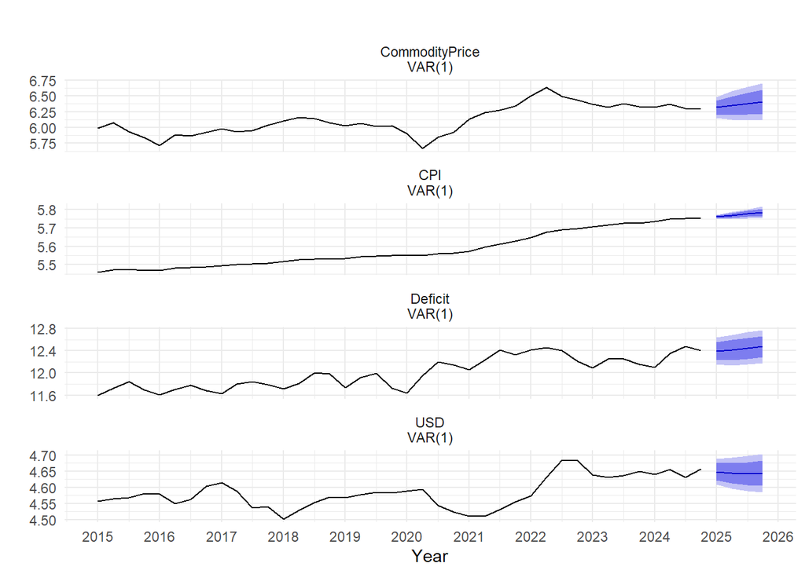

```r
# Fit a VAR(1) model including both a constant and trend
fit <- VAR(data, p = 1, type = "both")
forecast(fit, h=h) %>%
  autoplot() +
  scale_x_continuous(breaks = 2015:2027) +
  xlab("Year") +
  theme_minimal()
```

I believe the forecast is very good. The VAR(1) model has effectively captured the pattern of four varibales.

## VAR: USD ~ Interest Rate + CPI + Unemployment Rate + GDP

Let’s now analyze how macroeconomic variables, such as interest rate, CPI, unemployment rate, and GDP, interact with the US Dollar Index.

**Time Series Plot**

```r
ir_q <- ir %>%
  mutate(quarter = floor_date(Date, "quarter")) %>%
  group_by(quarter) %>%
  summarise(IR = mean(IR, na.rm = TRUE))
unem_q <- data_unem %>%
  mutate(quarter = floor_date(time, "quarter")) %>%
  group_by(quarter) %>%
  summarise(unem = mean(unem, na.rm = TRUE))

df2 <- data.frame(Date = dxy_q$quarter,
                  USD = log(dxy_q$Close),
                  InterestRate = log(ir_q$IR),
                  CPI = log(cpi_q$cpi),
                  UnemploymentRate = log(unem_q$unem),
                  GDP = log(gdp$total)
                  )

plot_usd <- plot_ly(df2, x = ~Date, y = ~USD, type = 'scatter', mode = 'lines', name = 'U.S. Dollar')
plot_ir <- plot_ly(df2, x = ~Date, y = ~InterestRate, type = 'scatter', mode = 'lines', name = 'Interest Rate')
plot_cpi <- plot_ly(df2, x = ~Date, y = ~CPI, type = 'scatter', mode = 'lines', name = 'CPI')
plot_unem <- plot_ly(df2, x = ~Date, y = ~UnemploymentRate, type = 'scatter', mode = 'lines', name = 'unemployment Rate')
plot_gdp <- plot_ly(df2, x = ~Date, y = ~GDP, type = 'scatter', mode = 'lines', name = 'GDP')

subplot(plot_usd, plot_ir, plot_cpi, plot_unem, plot_gdp, nrows = 5, shareX = TRUE) %>%
  layout(title = "Trend of U.S. Dollar and Related Variables", showlegend = FALSE,
    xaxis = list(title = 'Date'),
    yaxis = list(title = 'U.S. Dollar'),
    yaxis2 = list(title = 'Interest Rate'),
    yaxis3 = list(title = 'CPI'),
    yaxis4 = list(title = 'Unemployment Rate'),
    yaxis5 = list(title = 'GDP'))
```

[interactive chart not shown]

The trend of the USD and interest rate is very similar.

**Parameter(p) Selection**

```r
ts_df2 <- ts(df2[,-1], start = c(2005,1), frequency = 4)
VARselect(ts_df2, lag.max=6, type="both")
```

```
$selection
AIC(n)  HQ(n)  SC(n) FPE(n)
     3      2      1      3

$criteria
                   1             2             3             4             5
AIC(n) -3.344277e+01 -3.397270e+01 -3.420058e+01 -3.417668e+01 -3.396877e+01
HQ(n)  -3.300805e+01 -3.322747e+01 -3.314483e+01 -3.281042e+01 -3.229200e+01
SC(n)  -3.235301e+01 -3.210454e+01 -3.155402e+01 -3.075172e+01 -2.976541e+01
FPE(n)  3.000693e-15  1.786960e-15  1.462198e-15  1.575617e-15  2.109013e-15
                   6
AIC(n) -3.389629e+01
HQ(n)  -3.190900e+01
SC(n)  -2.891453e+01
FPE(n)  2.577987e-15
```

Based on the results, the lag length could be 1, 2, or 3.

**Fit Models**

```r
summary(fit <- VAR(ts_df2, p=1, type="both"))
```

```
VAR Estimation Results:
=========================
Endogenous variables: USD, InterestRate, CPI, UnemploymentRate, GDP
Deterministic variables: both
Sample size: 79
Log Likelihood: 797.035
Roots of the characteristic polynomial:
1.022 0.8726 0.8726 0.7888 0.7888
Call:
VAR(y = ts_df2, p = 1, type = "both")


Estimation results for equation USD:
====================================
USD = USD.l1 + InterestRate.l1 + CPI.l1 + UnemploymentRate.l1 + GDP.l1 + const + trend

                      Estimate Std. Error t value Pr(>|t|)
USD.l1               0.8602541  0.0646797  13.300  < 2e-16 ***
InterestRate.l1     -0.0121483  0.0040616  -2.991 0.003805 **
CPI.l1               0.4560117  0.3075579   1.483 0.142522
UnemploymentRate.l1 -0.0894047  0.0253856  -3.522 0.000748 ***
GDP.l1              -0.2034453  0.2634512  -0.772 0.442505
const                0.2930808  1.3118642   0.223 0.823851
trend               -0.0004485  0.0012972  -0.346 0.730553
---
Signif. codes:  0 '***' 0.001 '**' 0.01 '*' 0.05 '.' 0.1 ' ' 1


Residual standard error: 0.02816 on 72 degrees of freedom
Multiple R-Squared: 0.9355, Adjusted R-squared: 0.9301
F-statistic:   174 on 6 and 72 DF,  p-value: < 2.2e-16


Estimation results for equation InterestRate:
=============================================
InterestRate = USD.l1 + InterestRate.l1 + CPI.l1 + UnemploymentRate.l1 + GDP.l1 + const + trend

                     Estimate Std. Error t value Pr(>|t|)
USD.l1                2.94889    1.09160   2.701   0.0086 **
InterestRate.l1       0.75927    0.06855  11.077   <2e-16 ***
```

[output cut: 78 more lines]

```
Covariance matrix of residuals:
                        USD InterestRate        CPI UnemploymentRate        GDP
USD               7.931e-04   -4.666e-05 -8.036e-05       -2.729e-05 -2.910e-05
InterestRate     -4.666e-05    2.259e-01  1.529e-03       -5.819e-02  5.515e-03
CPI              -8.036e-05    1.529e-03  5.334e-05       -2.209e-04  4.633e-05
UnemploymentRate -2.729e-05   -5.819e-02 -2.209e-04        2.339e-02 -2.023e-03
GDP              -2.910e-05    5.515e-03  4.633e-05       -2.023e-03  2.295e-04

Correlation matrix of residuals:
                       USD InterestRate     CPI UnemploymentRate      GDP
USD               1.000000    -0.003486 -0.3907        -0.006335 -0.06823
InterestRate     -0.003486     1.000000  0.4405        -0.800489  0.76601
CPI              -0.390712     0.440520  1.0000        -0.197793  0.41881
UnemploymentRate -0.006335    -0.800489 -0.1978         1.000000 -0.87316
GDP              -0.068225     0.766006  0.4188        -0.873164  1.00000
```

```r
summary(fit <- VAR(ts_df2, p=2, type="both"))
```

```
VAR Estimation Results:
=========================
Endogenous variables: USD, InterestRate, CPI, UnemploymentRate, GDP
Deterministic variables: both
Sample size: 78
Log Likelihood: 832.809
Roots of the characteristic polynomial:
1.018 0.9183 0.8712 0.8712 0.6637 0.6637 0.5249 0.5249 0.3718 0.116
Call:
VAR(y = ts_df2, p = 2, type = "both")


Estimation results for equation USD:
====================================
USD = USD.l1 + InterestRate.l1 + CPI.l1 + UnemploymentRate.l1 + GDP.l1 + USD.l2 + InterestRate.l2 + CPI.l2 + UnemploymentRate.l2 + GDP.l2 + const + trend

                     Estimate Std. Error t value Pr(>|t|)
USD.l1               1.243612   0.117284  10.603 6.82e-16 ***
InterestRate.l1     -0.001780   0.012031  -0.148    0.883
CPI.l1               0.493171   0.588521   0.838    0.405
UnemploymentRate.l1 -0.006097   0.051373  -0.119    0.906
GDP.l1               0.481614   0.464835   1.036    0.304
USD.l2              -0.499303   0.112295  -4.446 3.43e-05 ***
InterestRate.l2     -0.003618   0.011278  -0.321    0.749
CPI.l2              -0.171779   0.483045  -0.356    0.723
UnemploymentRate.l2 -0.069032   0.053140  -1.299    0.198
GDP.l2              -0.734841   0.491734  -1.494    0.140
const                1.940365   1.324816   1.465    0.148
trend                0.001211   0.001320   0.917    0.362
---
Signif. codes:  0 '***' 0.001 '**' 0.01 '*' 0.05 '.' 0.1 ' ' 1


Residual standard error: 0.02485 on 66 degrees of freedom
Multiple R-Squared: 0.9539, Adjusted R-squared: 0.9462
F-statistic: 124.1 on 11 and 66 DF,  p-value: < 2.2e-16


Estimation results for equation InterestRate:
=============================================
```

[output cut: 103 more lines]

```
Covariance matrix of residuals:
                        USD InterestRate        CPI UnemploymentRate        GDP
USD               6.177e-04   -0.0004103 -6.842e-05        0.0001653 -4.382e-05
InterestRate     -4.103e-04    0.2019778  1.376e-03       -0.0520121  4.928e-03
CPI              -6.842e-05    0.0013760  4.520e-05       -0.0002339  3.572e-05
UnemploymentRate  1.653e-04   -0.0520121 -2.339e-04        0.0217418 -1.914e-03
GDP              -4.382e-05    0.0049275  3.572e-05       -0.0019136  2.041e-04

Correlation matrix of residuals:
                      USD InterestRate     CPI UnemploymentRate     GDP
USD               1.00000     -0.03673 -0.4095          0.04512 -0.1234
InterestRate     -0.03673      1.00000  0.4554         -0.78488  0.7674
CPI              -0.40949      0.45542  1.0000         -0.23599  0.3719
UnemploymentRate  0.04512     -0.78488 -0.2360          1.00000 -0.9084
GDP              -0.12340      0.76742  0.3719         -0.90837  1.0000
```

```r
summary(fit <- VAR(ts_df2, p=3, type="both"))
```

```
VAR Estimation Results:
=========================
Endogenous variables: USD, InterestRate, CPI, UnemploymentRate, GDP
Deterministic variables: both
Sample size: 77
Log Likelihood: 852.23
Roots of the characteristic polynomial:
1.018 0.9244 0.917 0.917 0.7694 0.7694 0.6696 0.6696 0.5777 0.5777 0.5679 0.5679 0.5252 0.5252 0.479
Call:
VAR(y = ts_df2, p = 3, type = "both")


Estimation results for equation USD:
====================================
USD = USD.l1 + InterestRate.l1 + CPI.l1 + UnemploymentRate.l1 + GDP.l1 + USD.l2 + InterestRate.l2 + CPI.l2 + UnemploymentRate.l2 + GDP.l2 + USD.l3 + InterestRate.l3 + CPI.l3 + UnemploymentRate.l3 + GDP.l3 + const + trend

                      Estimate Std. Error t value Pr(>|t|)
USD.l1               1.3041007  0.1346595   9.684 7.09e-14 ***
InterestRate.l1     -0.0001496  0.0120338  -0.012  0.99012
CPI.l1               0.5322798  0.5861887   0.908  0.36749
UnemploymentRate.l1  0.0252092  0.0545618   0.462  0.64573
GDP.l1               0.6647715  0.5314519   1.251  0.21584
USD.l2              -0.6246021  0.1957419  -3.191  0.00226 **
InterestRate.l2     -0.0333759  0.0172772  -1.932  0.05811 .
CPI.l2               0.6049569  0.7416823   0.816  0.41792
UnemploymentRate.l2 -0.1299901  0.0752514  -1.727  0.08924 .
GDP.l2              -0.5487509  0.6584922  -0.833  0.40796
USD.l3               0.1774575  0.1265508   1.402  0.16599
InterestRate.l3      0.0241139  0.0112423   2.145  0.03602 *
CPI.l3              -0.1384671  0.5144835  -0.269  0.78875
UnemploymentRate.l3 -0.0170603  0.0552331  -0.309  0.75848
GDP.l3              -0.8993484  0.5469347  -1.644  0.10534
const                2.9549197  1.5195664   1.945  0.05652 .
trend                0.0020854  0.0014830   1.406  0.16484
---
Signif. codes:  0 '***' 0.001 '**' 0.01 '*' 0.05 '.' 0.1 ' ' 1


Residual standard error: 0.02368 on 60 degrees of freedom
Multiple R-Squared: 0.9619, Adjusted R-squared: 0.9518
```

[output cut: 128 more lines]

```
Covariance matrix of residuals:
                        USD InterestRate        CPI UnemploymentRate        GDP
USD               5.606e-04   -0.0007734 -5.581e-05        0.0003454 -6.159e-05
InterestRate     -7.734e-04    0.2035333  1.360e-03       -0.0514387  4.824e-03
CPI              -5.581e-05    0.0013605  3.833e-05       -0.0002594  3.925e-05
UnemploymentRate  3.454e-04   -0.0514387 -2.594e-04        0.0213112 -1.832e-03
GDP              -6.159e-05    0.0048239  3.925e-05       -0.0018322  1.923e-04

Correlation matrix of residuals:
                      USD InterestRate     CPI UnemploymentRate     GDP
USD               1.00000     -0.07241 -0.3807          0.09992 -0.1876
InterestRate     -0.07241      1.00000  0.4871         -0.78103  0.7710
CPI              -0.38072      0.48710  1.0000         -0.28699  0.4571
UnemploymentRate  0.09992     -0.78103 -0.2870          1.00000 -0.9050
GDP              -0.18757      0.77100  0.4571         -0.90501  1.0000
```

The model with p=1 or p=2 looks good. However, only a few variables are significant in the model with p=3. Next, we will perform cross-validation to determine the best model.

**Cross Validation**

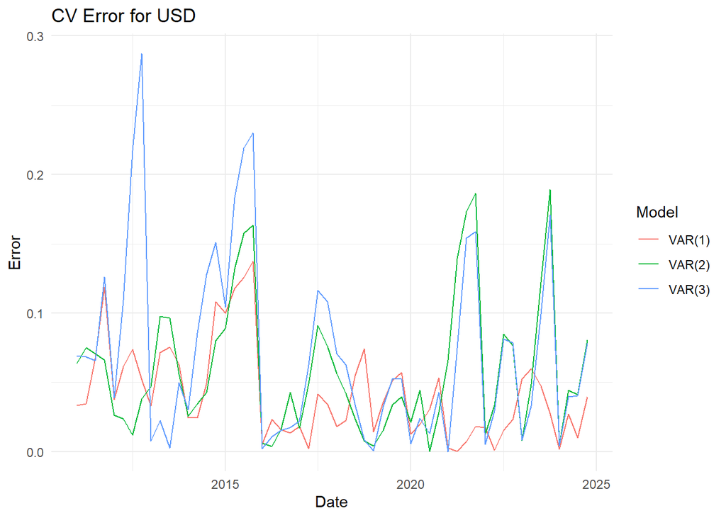

```r
fun.var.2 <- function(ts, year, p, s){
  fit <- VAR(ts, p=p, type='both')
  fcast <- predict(fit, n.ahead = s)

  f1<-fcast$fcst$USD
  f2<-fcast$fcst$InterestRate
  f3<-fcast$fcst$CPI
  f4<-fcast$fcst$UnemploymentRate
  f5<-fcast$fcst$GDP
  ff<-data.frame(f1[,1],f2[,1],f3[,1],f4[,1],f5[,1])
  ff<-ts(ff,start=c(year,1),frequency = s)
  return(ff)
}
data <- ts_df2
n=nrow(data)
n_var = ncol(data)
h <- 4  # h: Forecast horizon
# k: Initial training set
# Calculate k as 1/3rd of the data, rounded down to the nearest multiple of 12
k <- floor(n / 3 / h) * h
num_iter <- (n - k) / h  # Number of rolling iterations

# Initialize matrices for RMSE
rmse1 <- matrix(NA, nrow = n-k, ncol = n_var)  # RMSE for Model 1
rmse2 <- matrix(NA, nrow = n-k, ncol = n_var)  # RMSE for Model 2
rmse3 <- matrix(NA, nrow = n-k, ncol = n_var)  # RMSE for Model 3

# Define rolling start time
st <- tsp(data)[1] + (k - 1) / h

# Walk-Forward Validation Loop
for (i in 1:num_iter) {
  xtrain <- window(data, end = st + i - 1)
  xtest <- window(data, start = st + (i - 1) + 1/h, end = st + i)  # Test set for the next 12 months
  test_start_year <- st + (i-1) + 1/h #starting year for predication, i.e. xtest

  ######## VAR(1) ############
  ff1 <- fun.var.2(xtrain, test_start_year, p=1, s=h)
  ######## VAR(2) ############
  ff2 <- fun.var.2(xtrain, test_start_year, p=2, s=h)
  ######## VAR(3) ############
  ff3 <- fun.var.2(xtrain, test_start_year, p=3, s=h)

  ##### collecting errors ######
  a = h*i-h+1
  b= h*i
  rmse1[c(a:b),]  <-abs(ff1-xtest)
  rmse2[c(a:b),]  <-abs(ff2-xtest)
  rmse3[c(a:b),]  <-abs(ff3-xtest)
}

rmse_combined <- as.data.frame(rbind(rmse1, rmse2, rmse3))
colnames(rmse_combined) = c("USD","InterestRate","CPI","UnemploymentRate","GDP")
rmse_combined$Model <- c(rep("VAR(1)", n-k),rep("VAR(2)", n-k),rep("VAR(3)", n-k))
rmse_combined$Date <- time(data)[(k+1):n]

# Create the USD RMSE plot with a legend
ggplot(data = rmse_combined, aes(x = Date, y = USD, color = Model)) +
  geom_line() +
  labs(
    title = "CV Error for USD",
    x = "Date",
    y = "Error",
    color = "Model"
  ) +
  theme_minimal()
```

VAR(1) model is much better.

**Forecast**

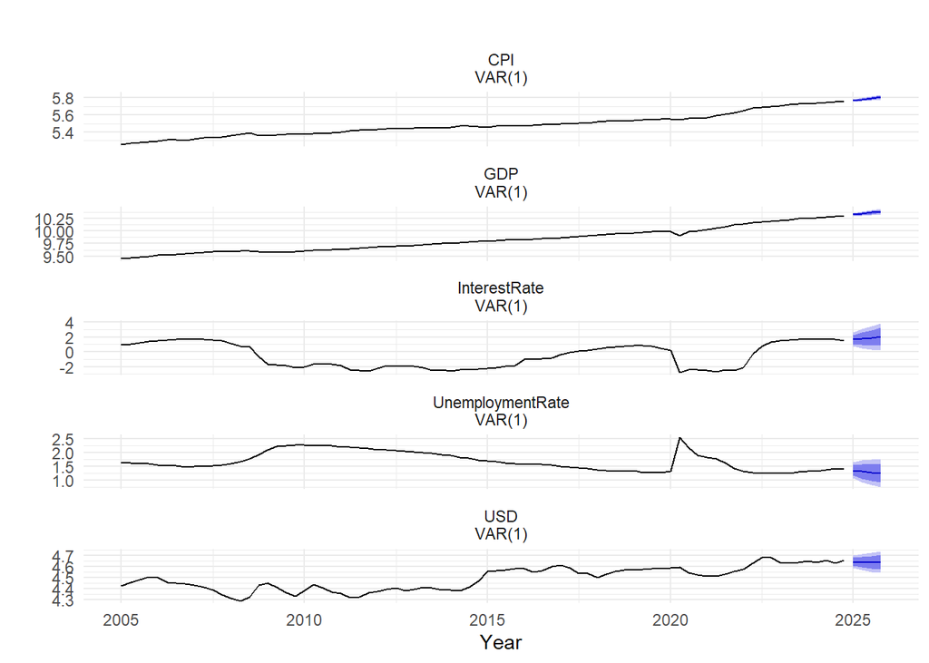

```r
# Fit a VAR(1) model including both a constant and trend
fit <- VAR(data, p = 1, type = "both")

forecast(fit, h=h) %>%
  autoplot() +
  xlab("Year") +
  theme_minimal()
```

I believe the forecast is very good. The VAR(1) model has effectively captured the pattern of five varibales.

## VAR: USD ~ Stock Price + Bitcoin Price

Now, let’s analyze how the US Dollar Index interacts with other financial assets, such as the S&P 500 Index and Bitcoin.

**Time Series Plot**

```r
# USD and S&P500 available on trading days
# Bitcoin prices (2015-2024) available daily

# Extract trading days
dxy_15 <- dxy[2523:dim(dxy)[1],]
sp5_15 <- GSPC[2518:dim(GSPC)[1],]
trading_days <- as.Date(intersect(as.Date(rownames(dxy_15)),as.Date(index(sp5_15))))
dxy_15 <- filter(dxy_15, Date %in% trading_days)
sp5_15 <- sp5_15[trading_days]
btc_15 <- `BTC-USD`[trading_days]

df3 <- data.frame(Date = dxy_15$Date,
                  USD = log(dxy_15$Close),
                  SP500 = log(sp5_15$GSPC.Close),
                  Bitcoin = log(btc_15[,"BTC-USD.Close"])
                  )
colnames(df3) <- c("Date", "USD", "SP500", "Bitcoin")

plot_usd <- plot_ly(df3, x = ~Date, y = ~USD, type = 'scatter', mode = 'lines', name = 'U.S. Dollar')
plot_sp5 <- plot_ly(df3, x = ~Date, y = ~SP500, type = 'scatter', mode = 'lines', name = 'S&P500 Index')
plot_btc <- plot_ly(df3, x = ~Date, y = ~Bitcoin, type = 'scatter', mode = 'lines', name = 'Bitcoin')

subplot(plot_usd, plot_sp5, plot_btc, nrows = 3, shareX = TRUE) %>%
  layout(title = "Trend of U.S. Dollar and Related Variables", showlegend = FALSE,
    xaxis = list(title = 'Date'),
    yaxis = list(title = 'U.S. Dollar'),
    yaxis2 = list(title = 'S&P500 Index'),
    yaxis3 = list(title = 'Bitcoin'))
```

[interactive chart not shown]

**Parameter(p) Selection**

```r
ts_df3 <- ts(df3[,-1], start = c(2015,1), frequency = 252)
VARselect(ts_df3, lag.max=6, type="both")
```

```
$selection
AIC(n)  HQ(n)  SC(n) FPE(n)
     5      2      2      5

$criteria
                   1             2             3             4             5
AIC(n) -2.617662e+01 -2.620759e+01 -2.621035e+01 -2.620885e+01 -2.621068e+01
HQ(n)  -2.616396e+01 -2.618734e+01 -2.618251e+01 -2.617342e+01 -2.616766e+01
SC(n)  -2.614175e+01 -2.615181e+01 -2.613365e+01 -2.611123e+01 -2.609215e+01
FPE(n)  4.281929e-12  4.151340e-12  4.139908e-12  4.146114e-12  4.138518e-12
                   6
AIC(n) -2.620763e+01
HQ(n)  -2.615701e+01
SC(n)  -2.606817e+01
FPE(n)  4.151193e-12
```

Based on the results, the lag length could be 2 or 5.

**Fit Models**

```r
summary(fit <- VAR(ts_df3, p=2, type="both"))
```

```
VAR Estimation Results:
=========================
Endogenous variables: USD, SP500, Bitcoin
Deterministic variables: both
Sample size: 2511
Log Likelihood: 22238.469
Roots of the characteristic polynomial:
0.998 0.9882 0.9882 0.1622 0.04563 0.009754
Call:
VAR(y = ts_df3, p = 2, type = "both")


Estimation results for equation USD:
====================================
USD = USD.l1 + SP500.l1 + Bitcoin.l1 + USD.l2 + SP500.l2 + Bitcoin.l2 + const + trend

             Estimate Std. Error t value Pr(>|t|)
USD.l1      1.004e+00  2.000e-02  50.213  < 2e-16 ***
SP500.l1   -4.421e-02  7.942e-03  -5.566 2.88e-08 ***
Bitcoin.l1  3.686e-04  2.039e-03   0.181   0.8566
USD.l2     -1.404e-02  2.003e-02  -0.701   0.4834
SP500.l2    4.576e-02  7.943e-03   5.762 9.36e-09 ***
Bitcoin.l2 -8.659e-04  2.038e-03  -0.425   0.6710
const       3.618e-02  1.998e-02   1.811   0.0703 .
trend       8.613e-07  7.377e-07   1.168   0.2431
---
Signif. codes:  0 '***' 0.001 '**' 0.01 '*' 0.05 '.' 0.1 ' ' 1


Residual standard error: 0.004332 on 2503 degrees of freedom
Multiple R-Squared: 0.9924, Adjusted R-squared: 0.9923
F-statistic: 4.641e+04 on 7 and 2503 DF,  p-value: < 2.2e-16


Estimation results for equation SP500:
======================================
SP500 = USD.l1 + SP500.l1 + Bitcoin.l1 + USD.l2 + SP500.l2 + Bitcoin.l2 + const + trend

             Estimate Std. Error t value Pr(>|t|)
USD.l1     -1.135e-01  5.142e-02  -2.207  0.02738 *
```

[output cut: 35 more lines]

```
F-statistic: 5.993e+05 on 7 and 2503 DF,  p-value: < 2.2e-16



Covariance matrix of residuals:
               USD      SP500    Bitcoin
USD      1.877e-05 -6.093e-06 -1.548e-05
SP500   -6.093e-06  1.241e-04  1.100e-04
Bitcoin -1.548e-05  1.100e-04  1.898e-03

Correlation matrix of residuals:
             USD   SP500  Bitcoin
USD      1.00000 -0.1263 -0.08204
SP500   -0.12627  1.0000  0.22677
Bitcoin -0.08204  0.2268  1.00000
```

```r
summary(fit <- VAR(ts_df3, p=5, type="both"))
```

```
VAR Estimation Results:
=========================
Endogenous variables: USD, SP500, Bitcoin
Deterministic variables: both
Sample size: 2508
Log Likelihood: 22243.537
Roots of the characteristic polynomial:
0.9979 0.9884 0.9884 0.5469 0.5469 0.4885 0.4885 0.4613 0.4613 0.4553 0.4553 0.4274 0.4118 0.4118 0.2657
Call:
VAR(y = ts_df3, p = 5, type = "both")


Estimation results for equation USD:
====================================
USD = USD.l1 + SP500.l1 + Bitcoin.l1 + USD.l2 + SP500.l2 + Bitcoin.l2 + USD.l3 + SP500.l3 + Bitcoin.l3 + USD.l4 + SP500.l4 + Bitcoin.l4 + USD.l5 + SP500.l5 + Bitcoin.l5 + const + trend

             Estimate Std. Error t value Pr(>|t|)
USD.l1      1.004e+00  2.019e-02  49.692  < 2e-16 ***
SP500.l1   -4.489e-02  8.068e-03  -5.564 2.92e-08 ***
Bitcoin.l1  5.992e-04  2.046e-03   0.293   0.7696
USD.l2     -3.504e-02  2.858e-02  -1.226   0.2203
SP500.l2    4.381e-02  1.064e-02   4.117 3.96e-05 ***
Bitcoin.l2  1.722e-03  2.879e-03   0.598   0.5497
USD.l3     -2.433e-03  2.858e-02  -0.085   0.9322
SP500.l3   -6.585e-03  1.073e-02  -0.613   0.5396
Bitcoin.l3 -3.375e-03  2.879e-03  -1.172   0.2412
USD.l4      5.154e-02  2.848e-02   1.810   0.0705 .
SP500.l4    7.833e-03  1.063e-02   0.737   0.4612
Bitcoin.l4 -4.209e-03  2.878e-03  -1.462   0.1438
USD.l5     -2.700e-02  2.009e-02  -1.344   0.1792
SP500.l5    1.531e-03  8.087e-03   0.189   0.8499
Bitcoin.l5  4.790e-03  2.044e-03   2.344   0.0192 *
const       3.277e-02  2.024e-02   1.619   0.1056
trend       7.349e-07  7.459e-07   0.985   0.3246
---
Signif. codes:  0 '***' 0.001 '**' 0.01 '*' 0.05 '.' 0.1 ' ' 1


Residual standard error: 0.004329 on 2491 degrees of freedom
Multiple R-Squared: 0.9924, Adjusted R-squared: 0.9923
```

[output cut: 62 more lines]

```
F-statistic: 2.613e+05 on 16 and 2491 DF,  p-value: < 2.2e-16



Covariance matrix of residuals:
               USD      SP500    Bitcoin
USD      1.874e-05 -6.191e-06 -1.519e-05
SP500   -6.191e-06  1.225e-04  1.085e-04
Bitcoin -1.519e-05  1.085e-04  1.897e-03

Correlation matrix of residuals:
             USD   SP500  Bitcoin
USD      1.00000 -0.1292 -0.08059
SP500   -0.12921  1.0000  0.22495
Bitcoin -0.08059  0.2250  1.00000
```

The results looks similar. Next, we will perform cross-validation to determine the best model.

**Cross Validation**

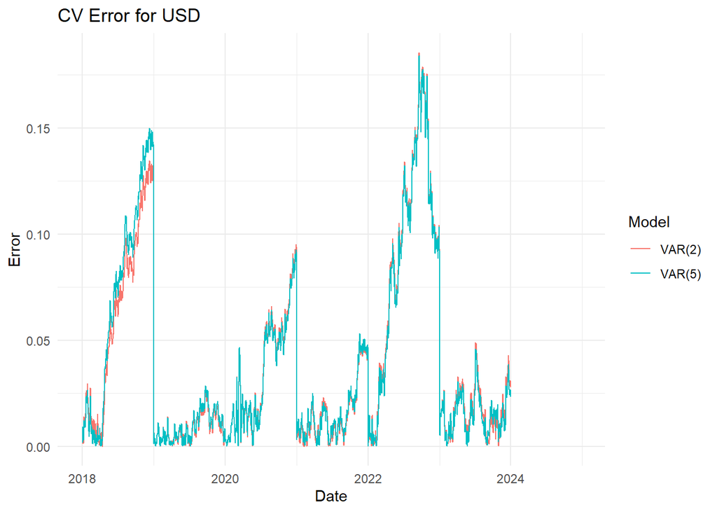

```r
fun.var.3 <- function(ts, year, p, s){
  fit <- VAR(ts, p=p, type='both')
  fcast <- predict(fit, n.ahead = s)

  f1<-fcast$fcst$USD
  f2<-fcast$fcst$SP500
  f3<-fcast$fcst$Bitcoin
  ff<-data.frame(f1[,1],f2[,1],f3[,1])
  ff<-ts(ff,start=c(year,1),frequency = s)
  return(ff)
}

data <- ts_df3
n=nrow(data)
n_var = ncol(data)
h <- 252  # h: Forecast horizon
# k: Initial training set
# Calculate k as 1/3rd of the data, rounded down to the nearest multiple of 12
k <- floor(n / 3 / h) * h
num_iter <- (n - k) / h  # Number of rolling iterations

# Initialize matrices for RMSE
rmse1 <- matrix(NA, nrow = n-k, ncol = n_var)  # RMSE for Model 1
rmse2 <- matrix(NA, nrow = n-k, ncol = n_var)  # RMSE for Model 2

# Define rolling start time
st <- tsp(data)[1] + (k - 1) / h

# Walk-Forward Validation Loop
for (i in 1:num_iter) {
  xtrain <- window(data, end = st + i - 1)
  xtest <- window(data, start = st + (i - 1) + 1/h, end = st + i)  # Test set for the next 12 months
  test_start_year <- st + (i-1) + 1/h #starting year for predication, i.e. xtest

  ######## VAR(2) ############
  ff1 <- fun.var.3(xtrain, test_start_year, p=2, s=h)
  ######## VAR(5) ############
  ff2 <- fun.var.3(xtrain, test_start_year, p=5, s=h)

  ##### collecting errors ######
  a = h*i-h+1
  b= h*i
  rmse1[c(a:b),]  <-abs(ff1-xtest)
  rmse2[c(a:b),]  <-abs(ff2-xtest)
}

rmse_combined <- as.data.frame(rbind(rmse1, rmse2))
colnames(rmse_combined) = c("USD","S&P500","Bitcoin")
rmse_combined$Model <- c(rep("VAR(2)", n-k),rep("VAR(5)", n-k))
rmse_combined$Date <- time(data)[(k+1):n]

# Create the USD RMSE plot with a legend
ggplot(data = rmse_combined, aes(x = Date, y = USD, color = Model)) +
  geom_line() +
  labs(
    title = "CV Error for USD",
    x = "Date",
    y = "Error",
    color = "Model"
  ) +
  theme_minimal()
```

The cross-validation results are very similar. Considering the principle of parsimony, we select VAR(2) as the best model.

**Forecast**

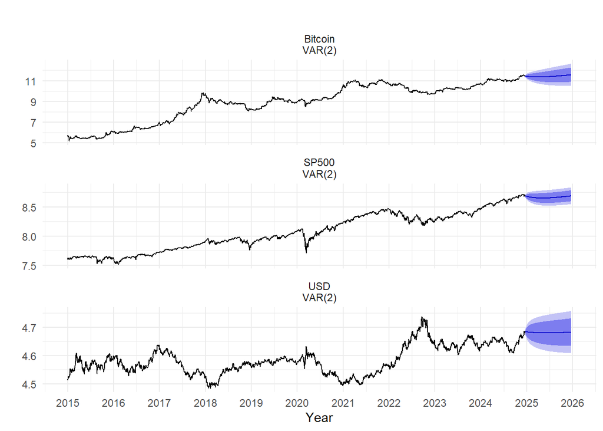

```r
# Fit a VAR(2) model including both a constant and trend
fit <- VAR(data, p = 2, type = "both")

forecast(fit, h=h) %>%
  autoplot() +
  scale_x_continuous(breaks = 2015:2026) +
  xlab("Year") +
  theme_minimal()
```

## VAR: USD ~ Oil Price + Gold Price

**Time Series Plot**

```r
xau_m <- xau %>%
  mutate(month = floor_date(Date, "month")) %>%
  group_by(month) %>%
  summarise(Price = mean(Price, na.rm = TRUE))

df4 <- data.frame(Date = dxy_m$month,
                  USD = log(dxy_m$Close),
                  OilPrice = log(oil$Oil),
                  GoldPrice = log(xau_m$Price)
                  )

plot_usd <- plot_ly(df4, x = ~Date, y = ~USD, type = 'scatter', mode = 'lines', name = 'U.S. Dollar')
plot_oil <- plot_ly(df4, x = ~Date, y = ~OilPrice, type = 'scatter', mode = 'lines', name = 'Oil Price')
plot_gold <- plot_ly(df4, x = ~Date, y = ~GoldPrice, type = 'scatter', mode = 'lines', name = 'Gold Price')

subplot(plot_usd, plot_oil, plot_gold, nrows = 3, shareX = TRUE) %>%
  layout(title = "Trend of U.S. Dollar and Related Variables", showlegend = FALSE,
    xaxis = list(title = 'Date'),
    yaxis = list(title = 'U.S. Dollar'),
    yaxis2 = list(title = 'Crude Oil Price'),
    yaxis3 = list(title = 'Gold Price'))
```

[interactive chart not shown]

We can see that the USD and oil prices tend to move in opposite directions.

**Parameter(p) Selection**

```r
ts_df4 <- ts(df4[,-1], start = c(2005,1), frequency = 12)
VARselect(ts_df4, lag.max=6, type="both")
```

```
$selection
AIC(n)  HQ(n)  SC(n) FPE(n)
     2      2      2      2

$criteria
                   1             2             3             4             5
AIC(n) -1.937674e+01 -1.952636e+01 -1.948332e+01 -1.946905e+01 -1.944988e+01
HQ(n)  -1.928743e+01 -1.938347e+01 -1.928684e+01 -1.921899e+01 -1.914624e+01
SC(n)  -1.915525e+01 -1.917197e+01 -1.899603e+01 -1.884887e+01 -1.869680e+01
FPE(n)  3.844119e-09  3.310129e-09  3.456157e-09  3.506587e-09  3.575685e-09
                   6
AIC(n) -1.938645e+01
HQ(n)  -1.902922e+01
SC(n)  -1.850047e+01
FPE(n)  3.811676e-09
```

VAR(2) is selected as the best model. But we will further validate this choice through model diagnostics and cross-validation.

**Fit models**

```r
summary(fit <- VAR(ts_df4, p=1, type="both"))
```

```
VAR Estimation Results:
=========================
Endogenous variables: USD, OilPrice, GoldPrice
Deterministic variables: both
Sample size: 239
Log Likelihood: 1314.286
Roots of the characteristic polynomial:
0.9684 0.9331 0.9331
Call:
VAR(y = ts_df4, p = 1, type = "both")


Estimation results for equation USD:
====================================
USD = USD.l1 + OilPrice.l1 + GoldPrice.l1 + const + trend

               Estimate Std. Error t value Pr(>|t|)
USD.l1        9.410e-01  2.727e-02  34.502  < 2e-16 ***
OilPrice.l1   7.723e-03  4.265e-03   1.811  0.07145 .
GoldPrice.l1 -1.745e-02  7.716e-03  -2.262  0.02464 *
const         3.367e-01  1.620e-01   2.079  0.03874 *
trend         1.734e-04  6.664e-05   2.602  0.00986 **
---
Signif. codes:  0 '***' 0.001 '**' 0.01 '*' 0.05 '.' 0.1 ' ' 1


Residual standard error: 0.01713 on 234 degrees of freedom
Multiple R-Squared: 0.9746, Adjusted R-squared: 0.9742
F-statistic:  2246 on 4 and 234 DF,  p-value: < 2.2e-16


Estimation results for equation OilPrice:
=========================================
OilPrice = USD.l1 + OilPrice.l1 + GoldPrice.l1 + const + trend

               Estimate Std. Error t value Pr(>|t|)
USD.l1       -2.541e-01  1.666e-01  -1.525    0.129
OilPrice.l1   9.008e-01  2.606e-02  34.567   <2e-16 ***
GoldPrice.l1  2.492e-02  4.715e-02   0.529    0.598
const         1.374e+00  9.897e-01   1.388    0.166
```

[output cut: 26 more lines]

```
F-statistic:  6642 on 4 and 234 DF,  p-value: < 2.2e-16



Covariance matrix of residuals:
                 USD   OilPrice  GoldPrice
USD        0.0002933 -0.0004969 -0.0002689
OilPrice  -0.0004969  0.0109508  0.0001376
GoldPrice -0.0002689  0.0001376  0.0014632

Correlation matrix of residuals:
              USD OilPrice GoldPrice
USD        1.0000 -0.27724  -0.41049
OilPrice  -0.2772  1.00000   0.03439
GoldPrice -0.4105  0.03439   1.00000
```

```r
summary(fit <- VAR(ts_df4, p=2, type="both"))
```

```
VAR Estimation Results:
=========================
Endogenous variables: USD, OilPrice, GoldPrice
Deterministic variables: both
Sample size: 238
Log Likelihood: 1334.167
Roots of the characteristic polynomial:
0.9707 0.8674 0.8674 0.4025 0.2636 0.1065
Call:
VAR(y = ts_df4, p = 2, type = "both")


Estimation results for equation USD:
====================================
USD = USD.l1 + OilPrice.l1 + GoldPrice.l1 + USD.l2 + OilPrice.l2 + GoldPrice.l2 + const + trend

               Estimate Std. Error t value Pr(>|t|)
USD.l1        1.2027754  0.0714199  16.841  < 2e-16 ***
OilPrice.l1  -0.0113234  0.0106528  -1.063  0.28892
GoldPrice.l1 -0.0131396  0.0306965  -0.428  0.66901
USD.l2       -0.2850616  0.0717925  -3.971 9.59e-05 ***
OilPrice.l2   0.0171081  0.0105528   1.621  0.10635
GoldPrice.l2 -0.0064260  0.0308520  -0.208  0.83519
const         0.4600009  0.1584409   2.903  0.00405 **
trend         0.0002079  0.0000649   3.204  0.00155 **
---
Signif. codes:  0 '***' 0.001 '**' 0.01 '*' 0.05 '.' 0.1 ' ' 1


Residual standard error: 0.01631 on 230 degrees of freedom
Multiple R-Squared: 0.9773, Adjusted R-squared: 0.9766
F-statistic:  1417 on 7 and 230 DF,  p-value: < 2.2e-16


Estimation results for equation OilPrice:
=========================================
OilPrice = USD.l1 + OilPrice.l1 + GoldPrice.l1 + USD.l2 + OilPrice.l2 + GoldPrice.l2 + const + trend

               Estimate Std. Error t value Pr(>|t|)
USD.l1       -3.476e-01  4.359e-01  -0.797    0.426
```

[output cut: 35 more lines]

```
F-statistic:  3670 on 7 and 230 DF,  p-value: < 2.2e-16



Covariance matrix of residuals:
                 USD   OilPrice  GoldPrice
USD        0.0002660 -0.0003718 -0.0002632
OilPrice  -0.0003718  0.0099101  0.0001536
GoldPrice -0.0002632  0.0001536  0.0014687

Correlation matrix of residuals:
              USD OilPrice GoldPrice
USD        1.0000 -0.22898  -0.42112
OilPrice  -0.2290  1.00000   0.04025
GoldPrice -0.4211  0.04025   1.00000
```

**Cross Validation**

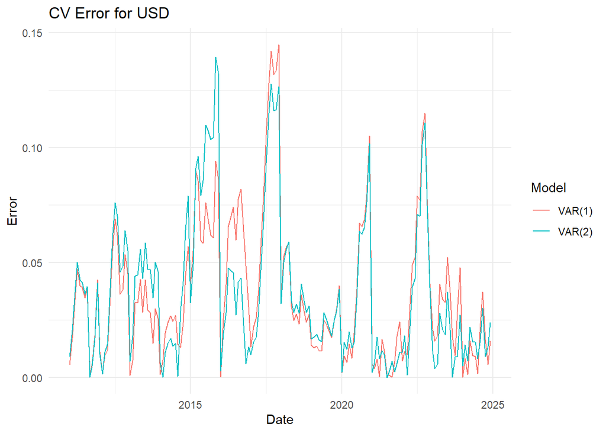

```r
fun.var.4 <- function(ts, year, p, s){
  fit <- VAR(ts, p=p, type='both')
  fcast <- predict(fit, n.ahead = s)

  f1<-fcast$fcst$USD
  f2<-fcast$fcst$OilPrice
  f3<-fcast$fcst$GoldPrice
  ff<-data.frame(f1[,1],f2[,1],f3[,1])
  ff<-ts(ff,start=c(year,1),frequency = s)
  return(ff)
}

data <- ts_df4
n=nrow(data)
n_var = ncol(data)
h <- 12  # h: Forecast horizon
# k: Initial training set
# Calculate k as 1/3rd of the data, rounded down to the nearest multiple of 12
k <- floor(n / 3 / h) * h
num_iter <- (n - k) / h  # Number of rolling iterations

# Initialize matrices for RMSE
rmse1 <- matrix(NA, nrow = n-k, ncol = n_var)  # RMSE for Model 1
rmse2 <- matrix(NA, nrow = n-k, ncol = n_var)  # RMSE for Model 2

# Define rolling start time
st <- tsp(data)[1] + (k - 1) / h

# Walk-Forward Validation Loop
for (i in 1:num_iter) {
  xtrain <- window(data, end = st + i - 1)
  xtest <- window(data, start = st + (i - 1) + 1/h, end = st + i)  # Test set for the next 12 months
  test_start_year <- st + (i-1) + 1/h #starting year for predication, i.e. xtest

  ######## VAR(1) ############
  ff1 <- fun.var.4(xtrain, test_start_year, p=1, s=h)
  ######## VAR(2) ############
  ff2 <- fun.var.4(xtrain, test_start_year, p=2, s=h)

  ##### collecting errors ######
  a = h*i-h+1
  b= h*i
  rmse1[c(a:b),]  <-abs(ff1-xtest)
  rmse2[c(a:b),]  <-abs(ff2-xtest)
}

rmse_combined <- as.data.frame(rbind(rmse1, rmse2))
colnames(rmse_combined) = c("USD","Oil Price","Gold Price")
rmse_combined$Model <- c(rep("VAR(1)", n-k),rep("VAR(2)", n-k))
rmse_combined$Date <- time(data)[(k+1):n]

# Create the USD RMSE plot with a legend
ggplot(data = rmse_combined, aes(x = Date, y = USD, color = Model)) +
  geom_line() +
  labs(
    title = "CV Error for USD",
    x = "Date",
    y = "Error",
    color = "Model"
  ) +
  theme_minimal()
```

The cross-validation result of VAR(1) is not significantly better than that of VAR(2). Therefore, we proceed with VAR(2) as suggested by `VARselect()`, since it has a lower AIC.

**Model Equation**

$$\begin{aligned}
\left[\begin{array}{l}
\hat{USD_t} \\ \hat{OilPrice_t} \\ \hat{GoldPrice_t}
\end{array}\right] &= \left[\begin{array}{ccc}
1.2027754 & -0.0113234 & -0.0131396 \\
-0.3476 & 1.201 & 0.1588 \\
-0.06861 & -0.02366 & 1.071
\end{array}\right] \left[\begin{array}{l}
\text{USD}_{t-1} \\
\text{OilPrice}_{t-1} \\
\text{GoldPrice}_{t-1} \\
\end{array}\right] \\
&+ \left[\begin{array}{ccc}
-0.2850616 & 0.0171081 & -0.0064260 \\
0.1539 & -0.3120 & -0.1185 \\
0.1107 & 0.01827 & -0.08309
\end{array}\right] \left[\begin{array}{l}
\text{USD}_{t-2} \\
\text{OilPrice}_{t-2} \\
\text{GoldPrice}_{t-2} \\
\end{array}\right]
\end{aligned}$$

**Forecast**

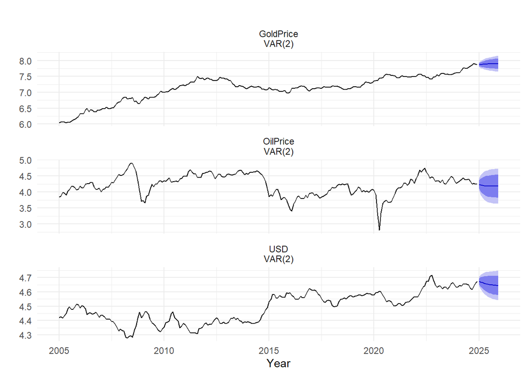

```r
# Fit a VAR(2) model including both a constant and trend
fit <- VAR(data, p = 2, type = "both")

forecast(fit, h=h) %>%
  autoplot() +
  xlab("Year") +
  theme_minimal()
```

## SARIMAX: USD ~ Egg Price

In this analysis, we will explore how the domestic market, specifically egg prices, affects the USD.

**Time Series Plot**

```r
df5 <- data.frame(Date = dxy_m$month, dxy = log(dxy_m$Close), egg = log(egg$Price))

plot_usd <- plot_ly(df5, x = ~Date, y = ~dxy, type = 'scatter', mode = 'lines', name = 'U.S. Dollar')
plot_egg <- plot_ly(df5, x = ~Date, y = ~egg, type = 'scatter', mode = 'lines', name = 'Egg Price')

subplot(plot_usd, plot_egg, nrows = 2, shareX = TRUE) %>%
  layout(title = "Trend of U.S. Dollar and Egg Price", showlegend = FALSE,
    xaxis = list(title = 'Date'),
    yaxis = list(title = 'U.S. Dollar'),
    yaxis2 = list(title = 'Egg Price'))
```

[interactive chart not shown]

The trend of the USD and egg prices is very similar. Thus, we can fit an ARIMAX model using the USD as the dependent variable and egg prices as the exogenous variable.

**auto.arima**

```r
ts_df5 <- ts(df5, start = c(2005, 1), frequency = 12)
auto.arima(ts_df5[,"dxy"], xreg = ts_df5[,"egg"])
```

```
Series: ts_df5[, "dxy"]
Regression with ARIMA(1,1,2)(2,0,1)[12] errors

Coefficients:
          ar1     ma1     ma2    sar1     sar2    sma1    xreg
      -0.9684  1.2983  0.3595  -0.704  -0.1496  0.5654  0.0019
s.e.   0.0264  0.0678  0.0635   0.449   0.0765  0.4505  0.0125

sigma^2 = 0.0002711:  log likelihood = 645.57
AIC=-1275.13   AICc=-1274.5   BIC=-1247.32
```

**Manual Search**

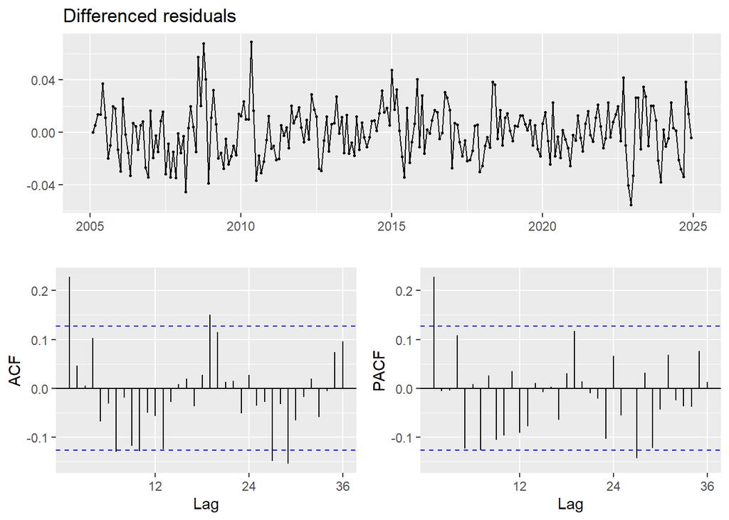

```r
# Fit a linear model
lm_fit.5 <- lm(dxy ~ egg, data = df5)
res.5 <- ts(residuals(lm_fit.5), start = c(2005, 1), frequency = 12)

# ACF and PACF plots of the residuals
ggtsdisplay(diff(res.5), main = "Differenced residuals") # p=0:1, d=1, q=0:1, P=0:3, D=1, Q=0:1
```

```r
# Manual search
output=SARIMA.c(p1=0,p2=1,q1=0,q2=1,P1=0,P2=3,Q1=0,Q2=1,s=12,data=res.5)
highlight_output(output)
```

Comparison of ARIMA Models

| p | d | q | P | D | Q | AIC | BIC | AICc |
| --- | --- | --- | --- | --- | --- | --- | --- | --- |
| 0 | 1 | 0 | 0 | 1 | 0 | -955.7432 | -952.3182 | -955.7254 |
| 0 | 1 | 0 | 0 | 1 | 1 | -1097.7315 | -1090.8816 | -1097.6779 |
| 0 | 1 | 0 | 1 | 1 | 0 | -1028.9996 | -1022.1497 | -1028.9460 |
| 0 | 1 | 0 | 1 | 1 | 1 | -1097.9083 | -1087.6334 | -1097.8007 |
| 0 | 1 | 0 | 2 | 1 | 0 | -1068.5904 | -1058.3155 | -1068.4828 |
| 0 | 1 | 0 | 2 | 1 | 1 | -1095.9367 | -1082.2369 | -1095.7565 |
| 0 | 1 | 0 | 3 | 1 | 0 | -1071.0916 | -1057.3918 | -1070.9114 |
| 0 | 1 | 0 | 3 | 1 | 1 | -1095.7146 | -1078.5899 | -1095.4431 |
| 0 | 1 | 1 | 0 | 1 | 0 | -972.4749 | -965.6250 | -972.4213 |
| 0 | 1 | 1 | 0 | 1 | 1 | -1108.1003 | -1097.8254 | -1107.9927 |
| 0 | 1 | 1 | 1 | 1 | 0 | -1045.4959 | -1035.2210 | -1045.3882 |
| 0 | 1 | 1 | 1 | 1 | 1 | -1107.3199 | -1093.6201 | -1107.1398 |
| 0 | 1 | 1 | 2 | 1 | 0 | -1076.4356 | -1062.7358 | -1076.2554 |
| 0 | 1 | 1 | 2 | 1 | 1 | -1105.3775 | -1088.2528 | -1105.1060 |
| 0 | 1 | 1 | 3 | 1 | 0 | -1078.2845 | -1061.1598 | -1078.0130 |
| 0 | 1 | 1 | 3 | 1 | 1 | -1104.3276 | -1083.7779 | -1103.9458 |
| 1 | 1 | 0 | 0 | 1 | 0 | -975.9562 | -969.1063 | -975.9027 |
| 1 | 1 | 0 | 0 | 1 | 1 | -1110.0948 | -1099.8199 | -1109.9872 |
| 1 | 1 | 0 | 1 | 1 | 0 | -1047.1080 | -1036.8331 | -1047.0003 |
| 1 | 1 | 0 | 1 | 1 | 1 | -1109.1529 | -1095.4531 | -1108.9727 |
| 1 | 1 | 0 | 2 | 1 | 0 | -1077.3774 | -1063.6776 | -1077.1972 |
| 1 | 1 | 0 | 2 | 1 | 1 | -1107.1979 | -1090.0731 | -1106.9264 |
| 1 | 1 | 0 | 3 | 1 | 0 | -1079.5166 | -1062.3919 | -1079.2451 |
| 1 | 1 | 0 | 3 | 1 | 1 | -1105.6125 | -1085.0628 | -1105.2306 |
| 1 | 1 | 1 | 0 | 1 | 0 | -974.5777 | -964.3029 | -974.4701 |
| 1 | 1 | 1 | 0 | 1 | 1 | -1108.5119 | -1094.8121 | -1108.3317 |
| 1 | 1 | 1 | 1 | 1 | 0 | -1045.1624 | -1031.4626 | -1044.9822 |
| 1 | 1 | 1 | 1 | 1 | 1 | -1107.5445 | -1090.4198 | -1107.2730 |
| 1 | 1 | 1 | 2 | 1 | 0 | -1075.5337 | -1058.4089 | -1075.2622 |
| 1 | 1 | 1 | 2 | 1 | 1 | -1105.5719 | -1085.0222 | -1105.1901 |
| 1 | 1 | 1 | 3 | 1 | 0 | -1077.8525 | -1057.3028 | -1077.4707 |
| 1 | 1 | 1 | 3 | 1 | 1 | -1104.2687 | -1080.2940 | -1103.7573 |

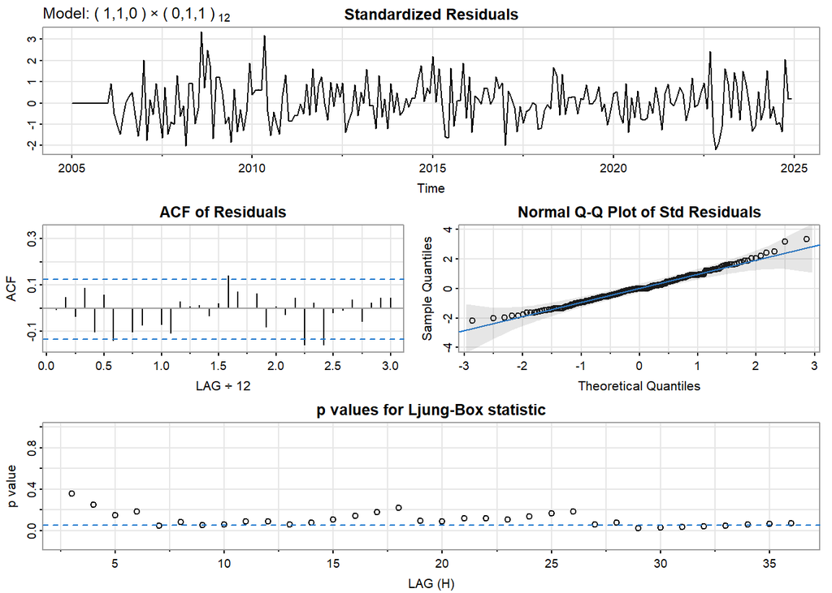

```r
# Model Diagnostics
model_output <- capture.output(sarima(res.5, 1,1,0,0,1,1,12))
```

```r
start_line <- grep("Coefficients", model_output)
end_line <- length(model_output)
cat(model_output[start_line:end_line], sep = "\n")
```

```
Coefficients:
     Estimate     SE  t.value p.value
ar1    0.2471 0.0641   3.8530   2e-04
sma1  -1.0000 0.0612 -16.3362   0e+00

sigma^2 estimated as 0.0003659517 on 225 degrees of freedom

AIC = -4.890285  AICc = -4.890049  BIC = -4.845022
```

The best model for the residuals of the linear model is ARIMA(1,1,0)(0,1,1)[12].

The Residual Plot of the ARIMA model shows nearly consistent fluctuation around zero, suggesting that the residuals are nearly stationary with a constant mean and finite variance over time.

The Autocorrelation Function (ACF) of the residuals shows mostly independence.

The Q-Q Plot indicates that the residuals follow a near-normal distribution, with minor deviations at the tails, which is typical in time series data.

The Ljung-Box Test p-values are mostly above the 0.05 significance level, implying that a few autocorrelations are left in the residuals.

All coefficients are significant at the 5% significant level.

**Cross Validation**

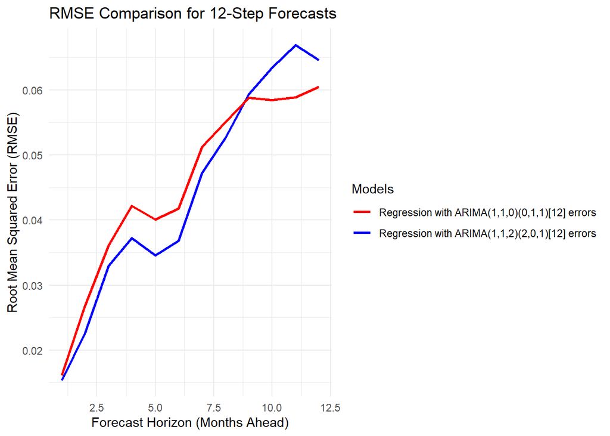

```r
# Define parameters
data <- ts_df5
n <- nrow(data)  # Total observations
h <- 12  # h: Forecast horizon
# k: Initial training set
# Calculate k as 1/3rd of the data, rounded down to the nearest multiple of 12
k <- floor(n / 3 / h) * h
num_iter <- (n - k) / h  # Number of rolling iterations

# Initialize matrices for RMSE
rmse1 <- matrix(NA, nrow = num_iter, ncol = h)  # RMSE for Model 1
rmse2 <- matrix(NA, nrow = num_iter, ncol = h)  # RMSE for Model 2

# Define rolling start time
st <- tsp(data)[1] + (k - 1) / h

# Walk-Forward Validation Loop
for (i in 1:num_iter) {
  xtrain <- window(data, end = st + i - 1)
  xtest <- window(data, start = st + (i - 1) + 1/h, end = st + i)  # Test set for the next 12 months

  # Fit auto.arima() model
  model.1 <- Arima(xtrain[,"dxy"], order = c(1,1,2),
                  seasonal = list(order = c(2,0,1), period = 12),
                  xreg = xtrain[, "egg"],
                  optim.control = list(maxit = 10000))
  f.1 <-   forecast(model.1, xreg = xtest[, "egg"], h = h)
  rmse1[i,] <-  (f.1$mean - xtest[,"dxy"])^2

  ###### Fit manual model
  model.2 <- Arima(xtrain[, "dxy"], order = c(1,1,0),
                  seasonal = list(order = c(0,1,1), period = 12),
                  xreg = xtrain[, "egg"],
                  optim.control = list(maxit = 10000))
  f.2 <- forecast(model.2, xreg = xtest[, "egg"], h = h)
  rmse2[i,] <-  (f.2$mean - xtest[,"dxy"])^2
}

# Compute RMSE across all iterations
rmse1_avg <- sqrt(colMeans(rmse1, na.rm = TRUE))
rmse2_avg <- sqrt(colMeans(rmse2, na.rm = TRUE))

# Create a DataFrame for better visualization
error_table <- data.frame(
    Horizon = 1:h,
    RMSE_Model1 = rmse1_avg,
    RMSE_Model2 = rmse2_avg
)

# **Improved RMSE Plot using ggplot2**
ggplot(error_table, aes(x = Horizon)) +
  geom_line(aes(y = RMSE_Model1, color = "Regression with ARIMA(1,1,2)(2,0,1)[12] errors"), size = 1) +
  geom_line(aes(y = RMSE_Model2, color = "Regression with ARIMA(1,1,0)(0,1,1)[12] errors"), size = 1) +
  labs(title = "RMSE Comparison for 12-Step Forecasts",
       x = "Forecast Horizon (Months Ahead)",
       y = "Root Mean Squared Error (RMSE)") +
  scale_color_manual(name = "Models", values = c("red", "blue")) +
  theme_minimal()
```

ARIMA(1,1,2)(2,0,1)[12] looks better.

**Model Equation**

Fit and summarize the best model:

```r
best_model <- Arima(data[,"dxy"], order = c(1,1,2),
                seasonal = list(order = c(2,0,1), period = 12),
                xreg = data[, "egg"],
                optim.control = list(maxit = 10000))
summary(best_model)
```

```
Series: data[, "dxy"]
Regression with ARIMA(1,1,2)(2,0,1)[12] errors

Coefficients:
          ar1     ma1     ma2    sar1     sar2    sma1    xreg
      -0.9684  1.2983  0.3595  -0.704  -0.1496  0.5654  0.0019
s.e.   0.0264  0.0678  0.0635   0.449   0.0765  0.4505  0.0125

sigma^2 = 0.0002711:  log likelihood = 645.57
AIC=-1275.13   AICc=-1274.5   BIC=-1247.32

Training set error measures:
                       ME       RMSE        MAE        MPE    MAPE      MASE
Training set 0.0009160148 0.01618699 0.01272872 0.01965128 0.28394 0.2172217
                    ACF1
Training set -0.01524275
```

**Model Equation**

$$\begin{gathered}
y_t=\beta x_t+n_t \\
\Phi_P\left(B^s\right) \varphi(B) \nabla_s^D \nabla^d n_t=\delta+\Theta_Q\left(B^s\right) \theta(B) w_t
\end{gathered}$$

With the parameters from the model:
$$\begin{gathered}
y_t=\beta x_t+n_t \\
y_t=0.0019 \text { Egg Price }+n_t
\end{gathered}$$

With $\operatorname{ARIMA}(1,1,2)(2,0,1)[12]$ errors:
$$\begin{gathered}
\Phi_P\left(B^{12}\right) \varphi(B) \nabla_{12}^{D=0} \nabla^{d=1} n_t=\Theta_Q\left(B^{12}\right) \theta(B) w_t \\
(1-\Phi_1 B^{12} - \Phi_2 B^{24})\left(1-\phi_1 B\right)(1-B) n_t=\left(1+\Theta B^{12}\right)\left(1+\theta_1 B+\theta_2 B^2\right) w_t \\
(1+0.704 B^{12} +0.1496 B^{24})\left(1+0.9684 B\right)(1-B) n_t=\left(1+0.5654 B^{12}\right)\left(1+1.2983 B+0.3595 B^2\right) w_t
\end{gathered}$$

**Forecast**

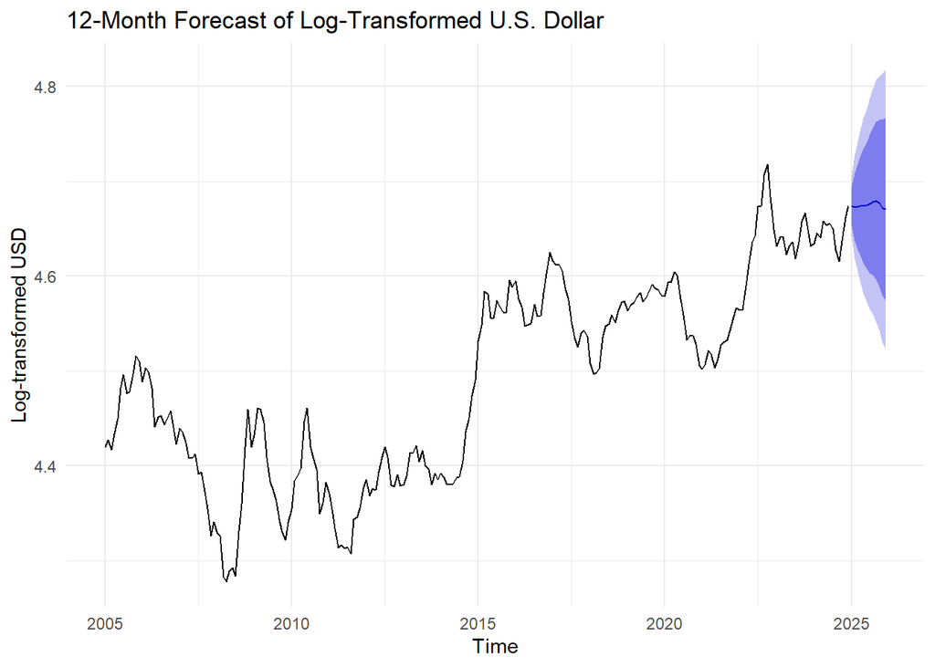

```r
arima_egg <- auto.arima(ts_df5[,"egg"])
f_egg <- forecast(arima_egg, h = h)
f.5 <-   forecast(best_model, xreg = f_egg$mean, h = h)
autoplot(f.5) +
  labs(title = "12-Month Forecast of Log-Transformed U.S. Dollar",
       x = "Time", y = "Log-transformed USD") +
  theme_minimal()
```

I believe the forecast is very good. By adding the exogenous variable (egg price) to the SARIMA model, the SARIMAX model has effectively captured the pattern of USD.

## ARIMAX: USD ~ House Price + International Visitors

Here, we will examine how the real estate and tourism market affect the USD.

**Time Series Plot**

```r
visitors_q <- visitors %>%
  mutate(quarter = floor_date(time, "quarter")) %>%
  group_by(quarter) %>%
  summarise(count = mean(count, na.rm = TRUE))
df6 <- data.frame(Date = dxy_q$quarter,
                  dxy = log(dxy_q$Close),
                  house = log(house$index),
                  visitors = log(visitors_q$count))
plot_usd <- plot_ly(df6, x = ~Date, y = ~dxy, type = 'scatter', mode = 'lines', name = 'U.S. Dollar')
plot_house <- plot_ly(df6, x = ~Date, y = ~house, type = 'scatter', mode = 'lines', name = 'House Price')
plot_visitors <- plot_ly(df6, x = ~Date, y = ~visitors, type = 'scatter', mode = 'lines', name = 'Visitors')

subplot(plot_usd, plot_house, plot_visitors, nrows = 3, shareX = TRUE) %>%
  layout(title = "Trend of U.S. Dollar and Related Variables ", showlegend = FALSE,
    xaxis = list(title = 'Date'),
    yaxis = list(title = 'U.S. Dollar'),
    yaxis2 = list(title = 'House Price'),
    yaxis3 = list(title = "Num of Intl Visitors"))
```

[interactive chart not shown]

Both the USD and house prices show an upward trend. Thus, we can fit an ARIMAX model using the USD as the dependent variable, house prices and international visitors as the exogenous variables.

**auto.arima**

```r
ts_df6 <- ts(df6, start = c(2005, 1), frequency = 4)
auto.arima(ts_df6[,"dxy"], xreg = ts_df6[,c("house", "visitors")])
```

```
Series: ts_df6[, "dxy"]
Regression with ARIMA(0,1,1) errors

Coefficients:
         ma1   house  visitors
      0.4995  0.3585   -0.0118
s.e.  0.0878  0.2114    0.0071

sigma^2 = 0.0007382:  log likelihood = 174.14
AIC=-340.28   AICc=-339.74   BIC=-330.8
```

**Manual Search**

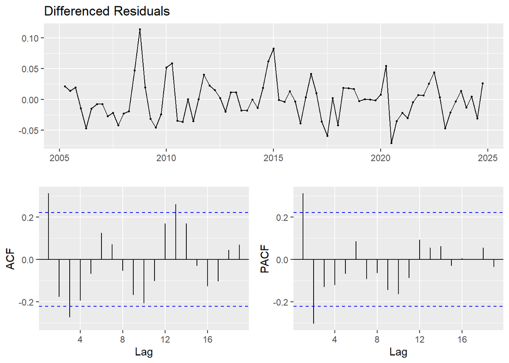

```r
# Fit a linear model
lm_fit.6 <- lm(dxy ~ house + visitors, data = df6)
res.6 <- ts(residuals(lm_fit.6), start = c(2005, 1), frequency = 4)

# ACF and PACF plots of the residuals
ggtsdisplay(diff(res.6), main = "Differenced Residuals") # p=0:2, d=1, q=0:3
```

```r
# Manual search
output=ARIMA.c(p1=0,p2=2,q1=0,q2=3,data=res.6)
highlight_output(output)
```

Comparison of ARIMA Models

| p | d | q | AIC | BIC | AICc |
| --- | --- | --- | --- | --- | --- |
| 0 | 1 | 0 | -315.2008 | -310.4620 | -315.0430 |
| 0 | 1 | 1 | -325.5822 | -318.4739 | -325.2622 |
| 0 | 1 | 2 | -323.6752 | -314.1974 | -323.1346 |
| 0 | 1 | 3 | -326.5282 | -314.6809 | -325.7062 |
| 1 | 1 | 0 | -321.2992 | -314.1908 | -320.9792 |
| 1 | 1 | 1 | -323.6205 | -314.1428 | -323.0800 |
| 1 | 1 | 2 | -328.3456 | -316.4983 | -327.5237 |
| 1 | 1 | 3 | -327.2125 | -312.9958 | -326.0458 |
| 2 | 1 | 0 | -327.2298 | -317.7520 | -326.6893 |
| 2 | 1 | 1 | -327.7637 | -315.9165 | -326.9418 |
| 2 | 1 | 2 | -326.5323 | -312.3157 | -325.3657 |
| 2 | 1 | 3 | -324.5698 | -307.9837 | -322.9924 |

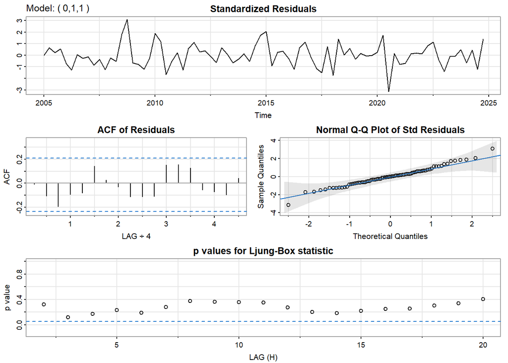

```r
# Model Diagnostics
model_output <- capture.output(sarima(res.6, 0,1,1))
```

```r
start_line <- grep("Coefficients", model_output)
end_line <- length(model_output)
cat(model_output[start_line:end_line], sep = "\n")
```

```
Coefficients:
         Estimate     SE t.value p.value
ma1        0.4289 0.0995  4.3111  0.0000
constant  -0.0001 0.0047 -0.0299  0.9763

sigma^2 estimated as 0.0008781503 on 77 degrees of freedom

AIC = -4.121294  AICc = -4.119295  BIC = -4.031315
```

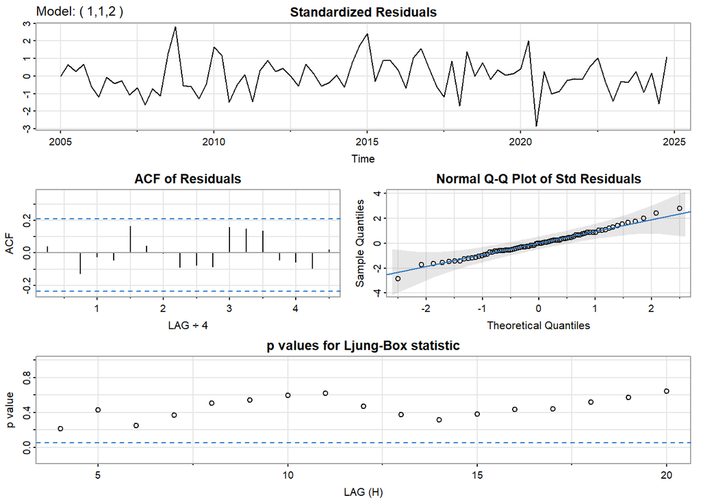

```r
model_output <- capture.output(sarima(res.6, 1,1,2))
```

```r
start_line <- grep("Coefficients", model_output)
end_line <- length(model_output)
cat(model_output[start_line:end_line], sep = "\n")
```

```
Coefficients:
         Estimate     SE t.value p.value
ar1        0.7855 0.0786  9.9877  0.0000
ma1       -0.5163 0.1041 -4.9618  0.0000
ma2       -0.4837 0.0977 -4.9491  0.0000
constant   0.0005 0.0008  0.5959  0.5531

sigma^2 estimated as 0.0007832046 on 75 degrees of freedom

AIC = -4.156273  AICc = -4.149431  BIC = -4.006308
```

For both models:

The Residual Plot of the ARIMA model shows nearly consistent fluctuation around zero, suggesting that the residuals are nearly stationary with a constant mean and finite variance over time.

The Autocorrelation Function (ACF) of the residuals shows perfectly independence.

The Q-Q Plot indicates that the residuals follow a near-normal distribution, with minor deviations at the tails, which is typical in time series data.

The Ljung-Box Test p-values are all above the 0.05 significance level, implying that no autocorrelations are left in the residuals.

**Cross Validation**

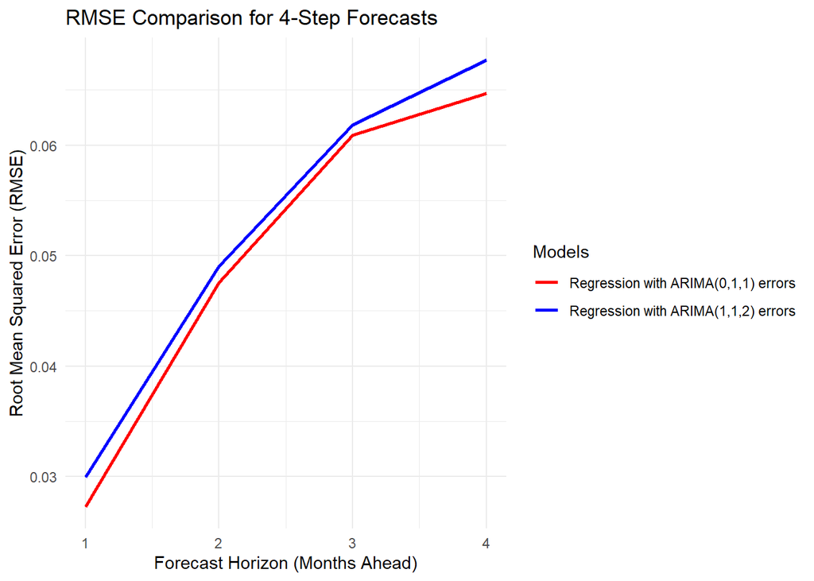

```r
# Define parameters
data <- ts_df6
n <- nrow(data)  # Total observations
h <- 4  # h: Forecast horizon
# k: Initial training set
# Calculate k as 1/3rd of the data, rounded down to the nearest multiple of 4
k <- floor(n / 3 / h) * h
num_iter <- (n - k) / h  # Number of rolling iterations

# Initialize matrices for RMSE
rmse1 <- matrix(NA, nrow = num_iter, ncol = h)  # RMSE for Model 1
rmse2 <- matrix(NA, nrow = num_iter, ncol = h)  # RMSE for Model 2

# Define rolling start time
st <- tsp(data)[1] + (k - 1) / h

# Walk-Forward Validation Loop
for (i in 1:num_iter) {
  xtrain <- window(data, end = st + i - 1)
  xtest <- window(data, start = st + (i - 1) + 1/h, end = st + i)  # Test set for the next 4 months

  # Fit auto.arima() model
  model.1 <- Arima(xtrain[,"dxy"], order = c(0,1,1),
                  xreg = xtrain[, c("house", "visitors")],
                  optim.control = list(maxit = 10000))
  f.1 <-   forecast(model.1, xreg = xtest[, c("house", "visitors")], h = h)
  rmse1[i,] <-  (f.1$mean - xtest[,"dxy"])^2

  ###### Fit manual model
  model.2 <- Arima(xtrain[, "dxy"], order = c(1,1,2),
                  xreg = xtrain[, c("house", "visitors")],
                  optim.control = list(maxit = 10000))
  f.2 <- forecast(model.2, xreg = xtest[, c("house", "visitors")], h = h)
  rmse2[i,] <-  (f.2$mean - xtest[,"dxy"])^2
}

# Compute RMSE across all iterations
rmse1_avg <- sqrt(colMeans(rmse1, na.rm = TRUE))
rmse2_avg <- sqrt(colMeans(rmse2, na.rm = TRUE))

# Create a DataFrame for better visualization
error_table <- data.frame(
    Horizon = 1:h,
    RMSE_Model1 = rmse1_avg,
    RMSE_Model2 = rmse2_avg
)

# **Improved RMSE Plot using ggplot2**
ggplot(error_table, aes(x = Horizon)) +
  geom_line(aes(y = RMSE_Model1, color = "Regression with ARIMA(0,1,1) errors"), size = 1) +
  geom_line(aes(y = RMSE_Model2, color = "Regression with ARIMA(1,1,2) errors"), size = 1) +
  labs(title = "RMSE Comparison for 4-Step Forecasts",
       x = "Forecast Horizon (Months Ahead)",
       y = "Root Mean Squared Error (RMSE)") +
  scale_color_manual(name = "Models", values = c("red", "blue")) +
  theme_minimal()
```

ARIMA(0,1,1) looks better.

**Model Equation**

Fit and summarize the best model:

```r
best_model <- Arima(data[,"dxy"], order = c(0,1,1),
                xreg = data[, c("house", "visitors")],
                optim.control = list(maxit = 10000))
summary(best_model)
```

```
Series: data[, "dxy"]
Regression with ARIMA(0,1,1) errors

Coefficients:
         ma1   house  visitors
      0.4995  0.3585   -0.0118
s.e.  0.0878  0.2114    0.0071

sigma^2 = 0.0007382:  log likelihood = 174.14
AIC=-340.28   AICc=-339.74   BIC=-330.8

Training set error measures:
                       ME       RMSE        MAE          MPE      MAPE
Training set 2.440354e-05 0.02648176 0.02082905 0.0001847146 0.4645378
                  MASE       ACF1
Training set 0.3713074 0.03777751
```

**Model Equation**

$$\begin{gathered}
y_t=\beta x_t+n_t \\
\varphi(B) \nabla^d n_t=\delta+ \theta(B) w_t
\end{gathered}$$

With the parameters from the model:
$$\begin{gathered}
y_t=\beta x_t+n_t \\
y_t=0.3585 \text { House Price } -0.0118 \text{International Visitors} +n_t
\end{gathered}$$

With $\operatorname{ARIMA}(0,1,1)$ errors:
$$\begin{gathered}
\varphi(B) \nabla^{d=1} n_t= \theta(B) w_t \\
(1-B) n_t=\left(1+\theta_1 B\right) w_t \\
(1-B) n_t=\left(1+0.4995 B\right) w_t
\end{gathered}$$

**Forecast**

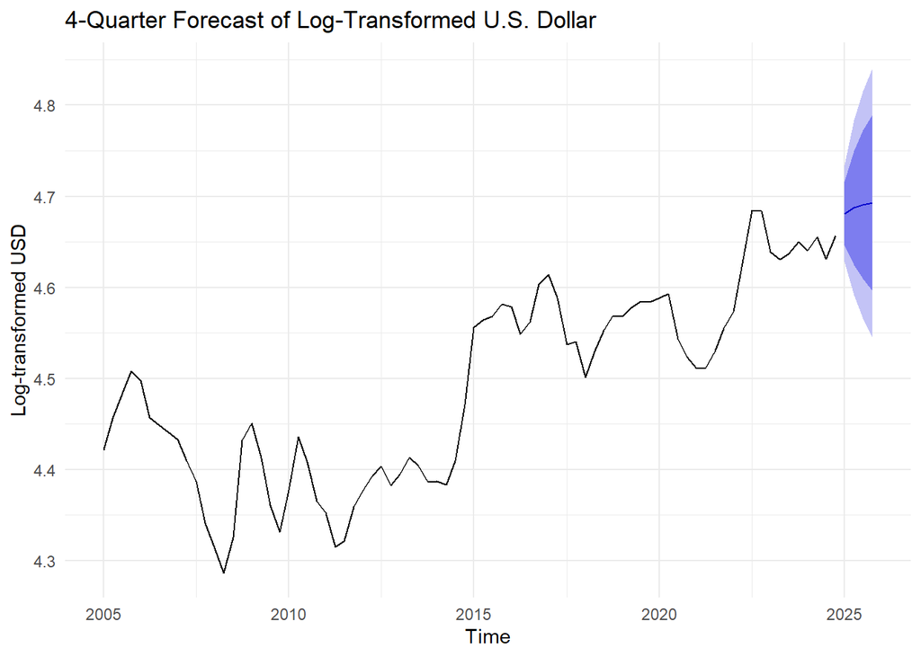

```r
arima_house <- auto.arima(ts_df6[,"house"])
f_house <- forecast(arima_house, h = h)
arima_visitors <- auto.arima(ts_df6[,"visitors"])
f_visitors <- forecast(arima_visitors, h = h)
xreg <- cbind(f_house$mean, f_visitors$mean)
colnames(xreg) <- c("house", "visitors")
f.6 <-   forecast(best_model, xreg = xreg, h = h)
autoplot(f.6) +
  labs(title = "4-Quarter Forecast of Log-Transformed U.S. Dollar",
       x = "Time", y = "Log-transformed USD") +
  theme_minimal()
```

I believe the forecast is very good. By adding the exogenous variables (house price and the number of international visitors) to the ARIMA model, the ARIMAX model has effectively captured the pattern of USD.

## Conclusion

🔹 First, to represent international trade, I built a VAR(1) model including the trade deficit, commodity prices, and the CPI.

The parameter matrix shows that a widening trade deficit leads to dollar depreciation, which aligns with economic intuition — a negative trade balance puts downward pressure on the currency. Commodity prices and the USD are also negatively correlated, likely reflecting that rising global commodity prices increase import costs. CPI, however, is positively related to the dollar, possibly due to expectations of tighter monetary policy in response to inflation.

🔹 Second, for macroeconomic fundamentals, I modeled the USD alongside interest rates, CPI, unemployment rate, and GDP.

The model suggests the dollar strengthens when interest rates, inflation, and GDP increase — which is consistent with capital inflows attracted by higher returns and a stronger economy. Unemployment, by contrast, is negatively related to the USD, reflecting that economic slack weakens confidence in the currency.

🔹 Third, I explored financial market dynamics using a VAR(2) model with S&P 500 and Bitcoin prices.

At lag one, the dollar and Bitcoin appear positively correlated — this may indicate that both are being used as alternative safe-haven assets. The S&P 500, however, is negatively related to the dollar, supporting the idea that when investors are optimistic about risky assets, the dollar tends to weaken.

🔹 Fourth, I examined the global commodity market with oil and gold prices in a VAR(2) framework.

As expected, gold is negatively related to the USD, consistent with its role as a traditional hedge when the dollar weakens. Oil also shows a negative relationship — rising oil prices may signal global inflation or geopolitical risks that weigh on the dollar. This finding also aligns with the earlier observation that the USD is negatively related to the global commodity price index.

🔹 Finally, to capture the real economy, I applied an ARIMAX(0,1,1) model using U.S. house prices and the number of international visitors.

House prices were positively related to the dollar, reflecting stronger domestic demand and investment sentiment. In contrast, international tourism had a negative effect — perhaps because a stronger dollar reduces the attractiveness of the U.S. as a travel destination. This model also produced an upward trend in the USD forecast.